# Sales_Forecasting_PRJ

**Sales Forecasting Project**

1. **Goal** : The goal of this project is to analyze historical sales data and build a machine learning model to predict future sales across different outlets and product categories.
2. **Libraries Used** : NumPy, Pandas, Matplotlib, Seaborn, Scikit-learn
3. **Built-in Python Modules Used** : os , warnings

**Steps Done**

1. **Data Collection** : Loaded the dataset into a pandas DataFrame and checked the structure, data types, and first few rows and all other informations.
2. **Data Cleaning** : Handled missing values , outliers , corrected invalid entries etc.
3. **EDA(Exploitary Data Analysis)** : Done functions like replacement , mapping , log transpromations etc.
4. **Visualization** : Used matplotlib and seaborn for visualization (countplot , distplot etc.) . Also printed correlation matrix using heatmap.
5. **ML Model** : *Goal* - Predict y using features X *Models Evaluated* : 1) Linear Models: Linear, Ridge, Lasso 2) Tree-based Models: Decision Tree, Random Forest, Extra Trees 3) Boosting Models: LightGBM, XGBoost *Evaluation Metrics* : 1) Negative Mean Squared Error (NMSE): Lower is better 2) R² Score: Higher is better *Conclusion* : 1) Deploy LightGBM Regressor for production. 2) Use RandomizedSearchCV tuned hyperparameters for optimal performance. 3) Keep Random Forest as a fallback or for feature analysis.

```python
import numpy as np
import pandas as pd
import seaborn as sns
import matplotlib.pyplot as plt
import os
import warnings
warnings.filterwarnings('ignore')
from matplotlib.pylab import rcParams
rcParams['figure.figsize']=15,6
```

```python
display (os.getcwd()) #get current working directory
```

```
'C:\\Users\\karwa'
```

```python
df=pd.read_csv("C:\\Users\\karwa\\OneDrive\\Documents\\Acmegrade\\Train.csv")
```

```python
df
```

|  | Item_Identifier | Item_Weight | Item_Fat_Content | Item_Visibility | Item_Type | Item_MRP | Outlet_Identifier | Outlet_Establishment_Year | Outlet_Size | Outlet_Location_Type | Outlet_Type | Item_Outlet_Sales |
| --- | --- | --- | --- | --- | --- | --- | --- | --- | --- | --- | --- | --- |
| 0 | FDA15 | 9.300 | Low Fat | 0.016047 | Dairy | 249.8092 | OUT049 | 1999 | Medium | Tier 1 | Supermarket Type1 | 3735.1380 |
| 1 | DRC01 | 5.920 | Regular | 0.019278 | Soft Drinks | 48.2692 | OUT018 | 2009 | Medium | Tier 3 | Supermarket Type2 | 443.4228 |
| 2 | FDN15 | 17.500 | Low Fat | 0.016760 | Meat | 141.6180 | OUT049 | 1999 | Medium | Tier 1 | Supermarket Type1 | 2097.2700 |
| 3 | FDX07 | 19.200 | Regular | 0.000000 | Fruits and Vegetables | 182.0950 | OUT010 | 1998 | NaN | Tier 3 | Grocery Store | 732.3800 |
| 4 | NCD19 | 8.930 | Low Fat | 0.000000 | Household | 53.8614 | OUT013 | 1987 | High | Tier 3 | Supermarket Type1 | 994.7052 |
| ... | ... | ... | ... | ... | ... | ... | ... | ... | ... | ... | ... | ... |
| 8518 | FDF22 | 6.865 | Low Fat | 0.056783 | Snack Foods | 214.5218 | OUT013 | 1987 | High | Tier 3 | Supermarket Type1 | 2778.3834 |
| 8519 | FDS36 | 8.380 | Regular | 0.046982 | Baking Goods | 108.1570 | OUT045 | 2002 | NaN | Tier 2 | Supermarket Type1 | 549.2850 |
| 8520 | NCJ29 | 10.600 | Low Fat | 0.035186 | Health and Hygiene | 85.1224 | OUT035 | 2004 | Small | Tier 2 | Supermarket Type1 | 1193.1136 |
| 8521 | FDN46 | 7.210 | Regular | 0.145221 | Snack Foods | 103.1332 | OUT018 | 2009 | Medium | Tier 3 | Supermarket Type2 | 1845.5976 |
| 8522 | DRG01 | 14.800 | Low Fat | 0.044878 | Soft Drinks | 75.4670 | OUT046 | 1997 | Small | Tier 1 | Supermarket Type1 | 765.6700 |

8523 rows × 12 columns

```python
df.head() #first 5 rows dsplayed
```

|  | Item_Identifier | Item_Weight | Item_Fat_Content | Item_Visibility | Item_Type | Item_MRP | Outlet_Identifier | Outlet_Establishment_Year | Outlet_Size | Outlet_Location_Type | Outlet_Type | Item_Outlet_Sales |
| --- | --- | --- | --- | --- | --- | --- | --- | --- | --- | --- | --- | --- |
| 0 | FDA15 | 9.30 | Low Fat | 0.016047 | Dairy | 249.8092 | OUT049 | 1999 | Medium | Tier 1 | Supermarket Type1 | 3735.1380 |
| 1 | DRC01 | 5.92 | Regular | 0.019278 | Soft Drinks | 48.2692 | OUT018 | 2009 | Medium | Tier 3 | Supermarket Type2 | 443.4228 |
| 2 | FDN15 | 17.50 | Low Fat | 0.016760 | Meat | 141.6180 | OUT049 | 1999 | Medium | Tier 1 | Supermarket Type1 | 2097.2700 |
| 3 | FDX07 | 19.20 | Regular | 0.000000 | Fruits and Vegetables | 182.0950 | OUT010 | 1998 | NaN | Tier 3 | Grocery Store | 732.3800 |
| 4 | NCD19 | 8.93 | Low Fat | 0.000000 | Household | 53.8614 | OUT013 | 1987 | High | Tier 3 | Supermarket Type1 | 994.7052 |

```python
print(df.shape) #no. of rows and columns
```

```
(8523, 12)
```

```python
print(df.info())
```

```
<class 'pandas.core.frame.DataFrame'>
RangeIndex: 8523 entries, 0 to 8522
Data columns (total 12 columns):
 #   Column                     Non-Null Count  Dtype
---  ------                     --------------  -----
 0   Item_Identifier            8523 non-null   object
 1   Item_Weight                7060 non-null   float64
 2   Item_Fat_Content           8523 non-null   object
 3   Item_Visibility            8523 non-null   float64
 4   Item_Type                  8523 non-null   object
 5   Item_MRP                   8523 non-null   float64
 6   Outlet_Identifier          8523 non-null   object
 7   Outlet_Establishment_Year  8523 non-null   int64
 8   Outlet_Size                6113 non-null   object
 9   Outlet_Location_Type       8523 non-null   object
 10  Outlet_Type                8523 non-null   object
 11  Item_Outlet_Sales          8523 non-null   float64
dtypes: float64(4), int64(1), object(7)
memory usage: 799.2+ KB
None
```

```python
print(df.describe(include='all'))
```

```
       Item_Identifier  Item_Weight Item_Fat_Content  Item_Visibility  \
count             8523  7060.000000             8523      8523.000000
unique            1559          NaN                5              NaN
top              FDW13          NaN          Low Fat              NaN
freq                10          NaN             5089              NaN
mean               NaN    12.857645              NaN         0.066132
std                NaN     4.643456              NaN         0.051598
min                NaN     4.555000              NaN         0.000000
25%                NaN     8.773750              NaN         0.026989
50%                NaN    12.600000              NaN         0.053931
75%                NaN    16.850000              NaN         0.094585
max                NaN    21.350000              NaN         0.328391

                    Item_Type     Item_MRP Outlet_Identifier  \
count                    8523  8523.000000              8523
unique                     16          NaN                10
top     Fruits and Vegetables          NaN            OUT027
freq                     1232          NaN               935
mean                      NaN   140.992782               NaN
std                       NaN    62.275067               NaN
min                       NaN    31.290000               NaN
25%                       NaN    93.826500               NaN
50%                       NaN   143.012800               NaN
75%                       NaN   185.643700               NaN
max                       NaN   266.888400               NaN

        Outlet_Establishment_Year Outlet_Size Outlet_Location_Type  \
count                 8523.000000        6113                 8523
unique                        NaN           3                    3
top                           NaN      Medium               Tier 3
freq                          NaN        2793                 3350
mean                  1997.831867         NaN                  NaN
std                      8.371760         NaN                  NaN
min                   1985.000000         NaN                  NaN
25%                   1987.000000         NaN                  NaN
50%                   1999.000000         NaN                  NaN
75%                   2004.000000         NaN                  NaN
max                   2009.000000         NaN                  NaN

              Outlet_Type  Item_Outlet_Sales
count                8523        8523.000000
unique                  4                NaN
top     Supermarket Type1                NaN
freq                 5577                NaN
mean                  NaN        2181.288914
std                   NaN        1706.499616
min                   NaN          33.290000
25%                   NaN         834.247400
50%                   NaN        1794.331000
75%                   NaN        3101.296400
max                   NaN       13086.964800
```

```python
#unique value count for each column
unique_counts=df.nunique()
print(unique_counts)
```

```
Item_Identifier              1559
Item_Weight                   415
Item_Fat_Content                5
Item_Visibility              7880
Item_Type                      16
Item_MRP                     5938
Outlet_Identifier              10
Outlet_Establishment_Year       9
Outlet_Size                     3
Outlet_Location_Type            3
Outlet_Type                     4
Item_Outlet_Sales            3493
dtype: int64
```

```python
#count of null values
df.isnull().sum() # columns having null values are : item_weight and outlet_size
```

```
Item_Identifier                 0
Item_Weight                  1463
Item_Fat_Content                0
Item_Visibility                 0
Item_Type                       0
Item_MRP                        0
Outlet_Identifier               0
Outlet_Establishment_Year       0
Outlet_Size                  2410
Outlet_Location_Type            0
Outlet_Type                     0
Item_Outlet_Sales               0
dtype: int64
```

```python
#highlighting null values
top_100=df.head(100)

def highlight_null(val):
    color="yellow" if pd.isnull(val) else ''
    return f'background-color:{color}'

color_null=top_100.style.applymap(highlight_null)
color_null
```

|  | Item_Identifier | Item_Weight | Item_Fat_Content | Item_Visibility | Item_Type | Item_MRP | Outlet_Identifier | Outlet_Establishment_Year | Outlet_Size | Outlet_Location_Type | Outlet_Type | Item_Outlet_Sales |
| --- | --- | --- | --- | --- | --- | --- | --- | --- | --- | --- | --- | --- |
| 0 | FDA15 | 9.300000 | Low Fat | 0.016047 | Dairy | 249.809200 | OUT049 | 1999 | Medium | Tier 1 | Supermarket Type1 | 3735.138000 |
| 1 | DRC01 | 5.920000 | Regular | 0.019278 | Soft Drinks | 48.269200 | OUT018 | 2009 | Medium | Tier 3 | Supermarket Type2 | 443.422800 |
| 2 | FDN15 | 17.500000 | Low Fat | 0.016760 | Meat | 141.618000 | OUT049 | 1999 | Medium | Tier 1 | Supermarket Type1 | 2097.270000 |
| 3 | FDX07 | 19.200000 | Regular | 0.000000 | Fruits and Vegetables | 182.095000 | OUT010 | 1998 | nan | Tier 3 | Grocery Store | 732.380000 |
| 4 | NCD19 | 8.930000 | Low Fat | 0.000000 | Household | 53.861400 | OUT013 | 1987 | High | Tier 3 | Supermarket Type1 | 994.705200 |
| 5 | FDP36 | 10.395000 | Regular | 0.000000 | Baking Goods | 51.400800 | OUT018 | 2009 | Medium | Tier 3 | Supermarket Type2 | 556.608800 |
| 6 | FDO10 | 13.650000 | Regular | 0.012741 | Snack Foods | 57.658800 | OUT013 | 1987 | High | Tier 3 | Supermarket Type1 | 343.552800 |
| 7 | FDP10 | nan | Low Fat | 0.127470 | Snack Foods | 107.762200 | OUT027 | 1985 | Medium | Tier 3 | Supermarket Type3 | 4022.763600 |
| 8 | FDH17 | 16.200000 | Regular | 0.016687 | Frozen Foods | 96.972600 | OUT045 | 2002 | nan | Tier 2 | Supermarket Type1 | 1076.598600 |
| 9 | FDU28 | 19.200000 | Regular | 0.094450 | Frozen Foods | 187.821400 | OUT017 | 2007 | nan | Tier 2 | Supermarket Type1 | 4710.535000 |
| 10 | FDY07 | 11.800000 | Low Fat | 0.000000 | Fruits and Vegetables | 45.540200 | OUT049 | 1999 | Medium | Tier 1 | Supermarket Type1 | 1516.026600 |
| 11 | FDA03 | 18.500000 | Regular | 0.045464 | Dairy | 144.110200 | OUT046 | 1997 | Small | Tier 1 | Supermarket Type1 | 2187.153000 |
| 12 | FDX32 | 15.100000 | Regular | 0.100014 | Fruits and Vegetables | 145.478600 | OUT049 | 1999 | Medium | Tier 1 | Supermarket Type1 | 1589.264600 |
| 13 | FDS46 | 17.600000 | Regular | 0.047257 | Snack Foods | 119.678200 | OUT046 | 1997 | Small | Tier 1 | Supermarket Type1 | 2145.207600 |
| 14 | FDF32 | 16.350000 | Low Fat | 0.068024 | Fruits and Vegetables | 196.442600 | OUT013 | 1987 | High | Tier 3 | Supermarket Type1 | 1977.426000 |
| 15 | FDP49 | 9.000000 | Regular | 0.069089 | Breakfast | 56.361400 | OUT046 | 1997 | Small | Tier 1 | Supermarket Type1 | 1547.319200 |
| 16 | NCB42 | 11.800000 | Low Fat | 0.008596 | Health and Hygiene | 115.349200 | OUT018 | 2009 | Medium | Tier 3 | Supermarket Type2 | 1621.888800 |
| 17 | FDP49 | 9.000000 | Regular | 0.069196 | Breakfast | 54.361400 | OUT049 | 1999 | Medium | Tier 1 | Supermarket Type1 | 718.398200 |
| 18 | DRI11 | nan | Low Fat | 0.034238 | Hard Drinks | 113.283400 | OUT027 | 1985 | Medium | Tier 3 | Supermarket Type3 | 2303.668000 |
| 19 | FDU02 | 13.350000 | Low Fat | 0.102492 | Dairy | 230.535200 | OUT035 | 2004 | Small | Tier 2 | Supermarket Type1 | 2748.422400 |
| 20 | FDN22 | 18.850000 | Regular | 0.138190 | Snack Foods | 250.872400 | OUT013 | 1987 | High | Tier 3 | Supermarket Type1 | 3775.086000 |
| 21 | FDW12 | nan | Regular | 0.035400 | Baking Goods | 144.544400 | OUT027 | 1985 | Medium | Tier 3 | Supermarket Type3 | 4064.043200 |
| 22 | NCB30 | 14.600000 | Low Fat | 0.025698 | Household | 196.508400 | OUT035 | 2004 | Small | Tier 2 | Supermarket Type1 | 1587.267200 |
| 23 | FDC37 | nan | Low Fat | 0.057557 | Baking Goods | 107.693800 | OUT019 | 1985 | Small | Tier 1 | Grocery Store | 214.387600 |
| 24 | FDR28 | 13.850000 | Regular | 0.025896 | Frozen Foods | 165.021000 | OUT046 | 1997 | Small | Tier 1 | Supermarket Type1 | 4078.025000 |
| 25 | NCD06 | 13.000000 | Low Fat | 0.099887 | Household | 45.906000 | OUT017 | 2007 | nan | Tier 2 | Supermarket Type1 | 838.908000 |
| 26 | FDV10 | 7.645000 | Regular | 0.066693 | Snack Foods | 42.311200 | OUT035 | 2004 | Small | Tier 2 | Supermarket Type1 | 1065.280000 |
| 27 | DRJ59 | 11.650000 | low fat | 0.019356 | Hard Drinks | 39.116400 | OUT013 | 1987 | High | Tier 3 | Supermarket Type1 | 308.931200 |
| 28 | FDE51 | 5.925000 | Regular | 0.161467 | Dairy | 45.508600 | OUT010 | 1998 | nan | Tier 3 | Grocery Store | 178.434400 |
| 29 | FDC14 | nan | Regular | 0.072222 | Canned | 43.645400 | OUT019 | 1985 | Small | Tier 1 | Grocery Store | 125.836200 |

[output cut: 70 more lines]

```python
#display unique values where data type is object
object_column=df.select_dtypes(include='object')
for col in object_column.columns:
    print(f"\nColumn: {col}")
    print(df[col].unique())
```

```
Column: Item_Identifier
['FDA15' 'DRC01' 'FDN15' ... 'NCF55' 'NCW30' 'NCW05']

Column: Item_Fat_Content
['Low Fat' 'Regular' 'low fat' 'LF' 'reg']

Column: Item_Type
['Dairy' 'Soft Drinks' 'Meat' 'Fruits and Vegetables' 'Household'
 'Baking Goods' 'Snack Foods' 'Frozen Foods' 'Breakfast'
 'Health and Hygiene' 'Hard Drinks' 'Canned' 'Breads' 'Starchy Foods'
 'Others' 'Seafood']

Column: Outlet_Identifier
['OUT049' 'OUT018' 'OUT010' 'OUT013' 'OUT027' 'OUT045' 'OUT017' 'OUT046'
 'OUT035' 'OUT019']

Column: Outlet_Size
['Medium' nan 'High' 'Small']

Column: Outlet_Location_Type
['Tier 1' 'Tier 3' 'Tier 2']

Column: Outlet_Type
['Supermarket Type1' 'Supermarket Type2' 'Grocery Store'
 'Supermarket Type3']
```

```python
#item_identifier and outlet_identifier only contains ID/Codes hence they are not required for ananlysis hence we will drop them.
object_columns = df.select_dtypes(include='object').drop(columns=['Item_Identifier','Outlet_Identifier'])
display(object_columns)
```

|  | Item_Fat_Content | Item_Type | Outlet_Size | Outlet_Location_Type | Outlet_Type |
| --- | --- | --- | --- | --- | --- |
| 0 | Low Fat | Dairy | Medium | Tier 1 | Supermarket Type1 |
| 1 | Regular | Soft Drinks | Medium | Tier 3 | Supermarket Type2 |
| 2 | Low Fat | Meat | Medium | Tier 1 | Supermarket Type1 |
| 3 | Regular | Fruits and Vegetables | NaN | Tier 3 | Grocery Store |
| 4 | Low Fat | Household | High | Tier 3 | Supermarket Type1 |
| ... | ... | ... | ... | ... | ... |
| 8518 | Low Fat | Snack Foods | High | Tier 3 | Supermarket Type1 |
| 8519 | Regular | Baking Goods | NaN | Tier 2 | Supermarket Type1 |
| 8520 | Low Fat | Health and Hygiene | Small | Tier 2 | Supermarket Type1 |
| 8521 | Regular | Snack Foods | Medium | Tier 3 | Supermarket Type2 |
| 8522 | Low Fat | Soft Drinks | Small | Tier 1 | Supermarket Type1 |

8523 rows × 5 columns

```python
#display unique values in category columns - count
for col in object_columns:
    print(col,len(df[col].unique())) # if we do one hot encoding then 5 columns will be item_fat_content and so on.
```

```
Item_Fat_Content 5
Item_Type 16
Outlet_Size 4
Outlet_Location_Type 3
Outlet_Type 4
```

```python
#unique values corresponding to each category with name and count
for col in object_columns.columns:
    print(f"\nColumn: {col}")
    print(df[col].value_counts())   # counts how many times each unique value appears in that column.
    print()
    print("*" * 50)
```

```
Column: Item_Fat_Content
Item_Fat_Content
Low Fat    5089
Regular    2889
LF          316
reg         117
low fat     112
Name: count, dtype: int64


Column: Item_Type
Item_Type
Fruits and Vegetables    1232
Snack Foods              1200
Household                 910
Frozen Foods              856
Dairy                     682
Canned                    649
Baking Goods              648
Health and Hygiene        520
Soft Drinks               445
Meat                      425
Breads                    251
Hard Drinks               214
Others                    169
Starchy Foods             148
Breakfast                 110
Seafood                    64
Name: count, dtype: int64


Column: Outlet_Size
Outlet_Size
Medium    2793
Small     2388
High       932
Name: count, dtype: int64


Column: Outlet_Location_Type
Outlet_Location_Type
Tier 3    3350
Tier 2    2785
Tier 1    2388
Name: count, dtype: int64


Column: Outlet_Type
Outlet_Type
Supermarket Type1    5577
Grocery Store        1083
Supermarket Type3     935
Supermarket Type2     928
Name: count, dtype: int64
```

```python
#displaying the missing values with count and percentage
missing_values = pd.DataFrame({
    'Missing Values': df.isnull().sum(),
    'Percentage': (df.isnull().sum() / len(df)) * 100
})
print(missing_values)
```

```
                           Missing Values  Percentage
Item_Identifier                         0    0.000000
Item_Weight                          1463   17.165317
Item_Fat_Content                        0    0.000000
Item_Visibility                         0    0.000000
Item_Type                               0    0.000000
Item_MRP                                0    0.000000
Outlet_Identifier                       0    0.000000
Outlet_Establishment_Year               0    0.000000
Outlet_Size                          2410   28.276428
Outlet_Location_Type                    0    0.000000
Outlet_Type                             0    0.000000
Item_Outlet_Sales                       0    0.000000
```

```python
#displaying bool value for missing values for column = 'Item Weight'
miss_bool=df['Item_Weight'].isnull()
display(miss_bool.head(20)) #true is returned in case of null values
```

```
0     False
1     False
2     False
3     False
4     False
5     False
6     False
7      True
8     False
9     False
10    False
11    False
12    False
13    False
14    False
15    False
16    False
17    False
18     True
19    False
Name: Item_Weight, dtype: bool
```

```python
#display all null records for column Item_Weight
Item_weight_null=df[df['Item_Weight'].isna()]
display(Item_weight_null) #shows records when item_weight will be null
```

|  | Item_Identifier | Item_Weight | Item_Fat_Content | Item_Visibility | Item_Type | Item_MRP | Outlet_Identifier | Outlet_Establishment_Year | Outlet_Size | Outlet_Location_Type | Outlet_Type | Item_Outlet_Sales |
| --- | --- | --- | --- | --- | --- | --- | --- | --- | --- | --- | --- | --- |
| 7 | FDP10 | NaN | Low Fat | 0.127470 | Snack Foods | 107.7622 | OUT027 | 1985 | Medium | Tier 3 | Supermarket Type3 | 4022.7636 |
| 18 | DRI11 | NaN | Low Fat | 0.034238 | Hard Drinks | 113.2834 | OUT027 | 1985 | Medium | Tier 3 | Supermarket Type3 | 2303.6680 |
| 21 | FDW12 | NaN | Regular | 0.035400 | Baking Goods | 144.5444 | OUT027 | 1985 | Medium | Tier 3 | Supermarket Type3 | 4064.0432 |
| 23 | FDC37 | NaN | Low Fat | 0.057557 | Baking Goods | 107.6938 | OUT019 | 1985 | Small | Tier 1 | Grocery Store | 214.3876 |
| 29 | FDC14 | NaN | Regular | 0.072222 | Canned | 43.6454 | OUT019 | 1985 | Small | Tier 1 | Grocery Store | 125.8362 |
| ... | ... | ... | ... | ... | ... | ... | ... | ... | ... | ... | ... | ... |
| 8485 | DRK37 | NaN | Low Fat | 0.043792 | Soft Drinks | 189.0530 | OUT027 | 1985 | Medium | Tier 3 | Supermarket Type3 | 6261.8490 |
| 8487 | DRG13 | NaN | Low Fat | 0.037006 | Soft Drinks | 164.7526 | OUT027 | 1985 | Medium | Tier 3 | Supermarket Type3 | 4111.3150 |
| 8488 | NCN14 | NaN | Low Fat | 0.091473 | Others | 184.6608 | OUT027 | 1985 | Medium | Tier 3 | Supermarket Type3 | 2756.4120 |
| 8490 | FDU44 | NaN | Regular | 0.102296 | Fruits and Vegetables | 162.3552 | OUT019 | 1985 | Small | Tier 1 | Grocery Store | 487.3656 |
| 8504 | NCN18 | NaN | Low Fat | 0.124111 | Household | 111.7544 | OUT027 | 1985 | Medium | Tier 3 | Supermarket Type3 | 4138.6128 |

1463 rows × 12 columns

```python
#null records with item_identifier column
Item_weight_null['Item_Identifier'].value_counts() #it shows the count of item identifier items when item weight is null . Eg : FDC14 appears 2 times
```

```
Item_Identifier
FDC14    2
FDV20    2
FDH10    2
FDW39    2
FDN34    2
        ..
FDS32    1
FDL10    1
FDT24    1
FDY28    1
FDC37    1
Name: count, Length: 1142, dtype: int64
```

```python
#for unique item_identifier values mean of item_weight is calculated
item_weight_mean=df.pivot_table(values='Item_Weight',index='Item_Identifier')
display(item_weight_mean)
```

| Item_Identifier | Item_Weight |
| --- | --- |
| DRA12 | 11.600 |
| DRA24 | 19.350 |
| DRA59 | 8.270 |
| DRB01 | 7.390 |
| DRB13 | 6.115 |
| ... | ... |
| NCZ30 | 6.590 |
| NCZ41 | 19.850 |
| NCZ42 | 10.500 |
| NCZ53 | 9.600 |
| NCZ54 | 14.650 |

1555 rows × 1 columns

```python
# Fill missing Item_Weight with the mean weight of each Item_Identifier
mean_value=df['Item_Weight'] = df['Item_Weight'].fillna(
    df.groupby('Item_Identifier')['Item_Weight'].transform('mean')
)
display(mean_value)
```

```
0        9.300
1        5.920
2       17.500
3       19.200
4        8.930
         ...
8518     6.865
8519     8.380
8520    10.600
8521     7.210
8522    14.800
Name: Item_Weight, Length: 8523, dtype: float64
```

```python
df.head(10)
```

|  | Item_Identifier | Item_Weight | Item_Fat_Content | Item_Visibility | Item_Type | Item_MRP | Outlet_Identifier | Outlet_Establishment_Year | Outlet_Size | Outlet_Location_Type | Outlet_Type | Item_Outlet_Sales |
| --- | --- | --- | --- | --- | --- | --- | --- | --- | --- | --- | --- | --- |
| 0 | FDA15 | 9.300 | Low Fat | 0.016047 | Dairy | 249.8092 | OUT049 | 1999 | Medium | Tier 1 | Supermarket Type1 | 3735.1380 |
| 1 | DRC01 | 5.920 | Regular | 0.019278 | Soft Drinks | 48.2692 | OUT018 | 2009 | Medium | Tier 3 | Supermarket Type2 | 443.4228 |
| 2 | FDN15 | 17.500 | Low Fat | 0.016760 | Meat | 141.6180 | OUT049 | 1999 | Medium | Tier 1 | Supermarket Type1 | 2097.2700 |
| 3 | FDX07 | 19.200 | Regular | 0.000000 | Fruits and Vegetables | 182.0950 | OUT010 | 1998 | NaN | Tier 3 | Grocery Store | 732.3800 |
| 4 | NCD19 | 8.930 | Low Fat | 0.000000 | Household | 53.8614 | OUT013 | 1987 | High | Tier 3 | Supermarket Type1 | 994.7052 |
| 5 | FDP36 | 10.395 | Regular | 0.000000 | Baking Goods | 51.4008 | OUT018 | 2009 | Medium | Tier 3 | Supermarket Type2 | 556.6088 |
| 6 | FDO10 | 13.650 | Regular | 0.012741 | Snack Foods | 57.6588 | OUT013 | 1987 | High | Tier 3 | Supermarket Type1 | 343.5528 |
| 7 | FDP10 | 19.000 | Low Fat | 0.127470 | Snack Foods | 107.7622 | OUT027 | 1985 | Medium | Tier 3 | Supermarket Type3 | 4022.7636 |
| 8 | FDH17 | 16.200 | Regular | 0.016687 | Frozen Foods | 96.9726 | OUT045 | 2002 | NaN | Tier 2 | Supermarket Type1 | 1076.5986 |
| 9 | FDU28 | 19.200 | Regular | 0.094450 | Frozen Foods | 187.8214 | OUT017 | 2007 | NaN | Tier 2 | Supermarket Type1 | 4710.5350 |

```python
#checking the null values again for item weight
result=df['Item_Weight'].isnull().sum()
display(result)
```

```
np.int64(4)
```

```python
#We are still lft with those missing values who have all their corresponding item identifier weight missing . So,Fill remaining NaNs with the global mean or median of the whole column.
df['Item_Weight'] = df['Item_Weight'].fillna(df['Item_Weight'].mean())
```

```python
df.head(20)
```

|  | Item_Identifier | Item_Weight | Item_Fat_Content | Item_Visibility | Item_Type | Item_MRP | Outlet_Identifier | Outlet_Establishment_Year | Outlet_Size | Outlet_Location_Type | Outlet_Type | Item_Outlet_Sales |
| --- | --- | --- | --- | --- | --- | --- | --- | --- | --- | --- | --- | --- |
| 0 | FDA15 | 9.300 | Low Fat | 0.016047 | Dairy | 249.8092 | OUT049 | 1999 | Medium | Tier 1 | Supermarket Type1 | 3735.1380 |
| 1 | DRC01 | 5.920 | Regular | 0.019278 | Soft Drinks | 48.2692 | OUT018 | 2009 | Medium | Tier 3 | Supermarket Type2 | 443.4228 |
| 2 | FDN15 | 17.500 | Low Fat | 0.016760 | Meat | 141.6180 | OUT049 | 1999 | Medium | Tier 1 | Supermarket Type1 | 2097.2700 |
| 3 | FDX07 | 19.200 | Regular | 0.000000 | Fruits and Vegetables | 182.0950 | OUT010 | 1998 | NaN | Tier 3 | Grocery Store | 732.3800 |
| 4 | NCD19 | 8.930 | Low Fat | 0.000000 | Household | 53.8614 | OUT013 | 1987 | High | Tier 3 | Supermarket Type1 | 994.7052 |
| 5 | FDP36 | 10.395 | Regular | 0.000000 | Baking Goods | 51.4008 | OUT018 | 2009 | Medium | Tier 3 | Supermarket Type2 | 556.6088 |
| 6 | FDO10 | 13.650 | Regular | 0.012741 | Snack Foods | 57.6588 | OUT013 | 1987 | High | Tier 3 | Supermarket Type1 | 343.5528 |
| 7 | FDP10 | 19.000 | Low Fat | 0.127470 | Snack Foods | 107.7622 | OUT027 | 1985 | Medium | Tier 3 | Supermarket Type3 | 4022.7636 |
| 8 | FDH17 | 16.200 | Regular | 0.016687 | Frozen Foods | 96.9726 | OUT045 | 2002 | NaN | Tier 2 | Supermarket Type1 | 1076.5986 |
| 9 | FDU28 | 19.200 | Regular | 0.094450 | Frozen Foods | 187.8214 | OUT017 | 2007 | NaN | Tier 2 | Supermarket Type1 | 4710.5350 |
| 10 | FDY07 | 11.800 | Low Fat | 0.000000 | Fruits and Vegetables | 45.5402 | OUT049 | 1999 | Medium | Tier 1 | Supermarket Type1 | 1516.0266 |
| 11 | FDA03 | 18.500 | Regular | 0.045464 | Dairy | 144.1102 | OUT046 | 1997 | Small | Tier 1 | Supermarket Type1 | 2187.1530 |
| 12 | FDX32 | 15.100 | Regular | 0.100014 | Fruits and Vegetables | 145.4786 | OUT049 | 1999 | Medium | Tier 1 | Supermarket Type1 | 1589.2646 |
| 13 | FDS46 | 17.600 | Regular | 0.047257 | Snack Foods | 119.6782 | OUT046 | 1997 | Small | Tier 1 | Supermarket Type1 | 2145.2076 |
| 14 | FDF32 | 16.350 | Low Fat | 0.068024 | Fruits and Vegetables | 196.4426 | OUT013 | 1987 | High | Tier 3 | Supermarket Type1 | 1977.4260 |
| 15 | FDP49 | 9.000 | Regular | 0.069089 | Breakfast | 56.3614 | OUT046 | 1997 | Small | Tier 1 | Supermarket Type1 | 1547.3192 |
| 16 | NCB42 | 11.800 | Low Fat | 0.008596 | Health and Hygiene | 115.3492 | OUT018 | 2009 | Medium | Tier 3 | Supermarket Type2 | 1621.8888 |
| 17 | FDP49 | 9.000 | Regular | 0.069196 | Breakfast | 54.3614 | OUT049 | 1999 | Medium | Tier 1 | Supermarket Type1 | 718.3982 |
| 18 | DRI11 | 8.260 | Low Fat | 0.034238 | Hard Drinks | 113.2834 | OUT027 | 1985 | Medium | Tier 3 | Supermarket Type3 | 2303.6680 |
| 19 | FDU02 | 13.350 | Low Fat | 0.102492 | Dairy | 230.5352 | OUT035 | 2004 | Small | Tier 2 | Supermarket Type1 | 2748.4224 |

```python
result=df['Item_Weight'].isnull().sum()
display(result) #all values clear
```

```
np.int64(0)
```

```python
#record count based on outlet size , filling the missing values
result=df.groupby('Outlet_Size').agg({'Outlet_Size':np.size}) #groupby :Groups the data by each unique size (Small, Medium, Large).
display(result)
```

| Outlet_Size | Outlet_Size |
| --- | --- |
| High | 932 |
| Medium | 2793 |
| Small | 2388 |

```python
#null records of outlet size
result=df['Outlet_Size'].isnull().sum()
display(result)
```

```
np.int64(2410)
```

```python
#showing records when outlet size is null
null_outlet_size=df[df['Outlet_Size'].isna()]
display(null_outlet_size)
```

|  | Item_Identifier | Item_Weight | Item_Fat_Content | Item_Visibility | Item_Type | Item_MRP | Outlet_Identifier | Outlet_Establishment_Year | Outlet_Size | Outlet_Location_Type | Outlet_Type | Item_Outlet_Sales |
| --- | --- | --- | --- | --- | --- | --- | --- | --- | --- | --- | --- | --- |
| 3 | FDX07 | 19.200 | Regular | 0.000000 | Fruits and Vegetables | 182.0950 | OUT010 | 1998 | NaN | Tier 3 | Grocery Store | 732.3800 |
| 8 | FDH17 | 16.200 | Regular | 0.016687 | Frozen Foods | 96.9726 | OUT045 | 2002 | NaN | Tier 2 | Supermarket Type1 | 1076.5986 |
| 9 | FDU28 | 19.200 | Regular | 0.094450 | Frozen Foods | 187.8214 | OUT017 | 2007 | NaN | Tier 2 | Supermarket Type1 | 4710.5350 |
| 25 | NCD06 | 13.000 | Low Fat | 0.099887 | Household | 45.9060 | OUT017 | 2007 | NaN | Tier 2 | Supermarket Type1 | 838.9080 |
| 28 | FDE51 | 5.925 | Regular | 0.161467 | Dairy | 45.5086 | OUT010 | 1998 | NaN | Tier 3 | Grocery Store | 178.4344 |
| ... | ... | ... | ... | ... | ... | ... | ... | ... | ... | ... | ... | ... |
| 8502 | NCH43 | 8.420 | Low Fat | 0.070712 | Household | 216.4192 | OUT045 | 2002 | NaN | Tier 2 | Supermarket Type1 | 3020.0688 |
| 8508 | FDW31 | 11.350 | Regular | 0.043246 | Fruits and Vegetables | 199.4742 | OUT045 | 2002 | NaN | Tier 2 | Supermarket Type1 | 2587.9646 |
| 8509 | FDG45 | 8.100 | Low Fat | 0.214306 | Fruits and Vegetables | 213.9902 | OUT010 | 1998 | NaN | Tier 3 | Grocery Store | 424.7804 |
| 8514 | FDA01 | 15.000 | Regular | 0.054489 | Canned | 57.5904 | OUT045 | 2002 | NaN | Tier 2 | Supermarket Type1 | 468.7232 |
| 8519 | FDS36 | 8.380 | Regular | 0.046982 | Baking Goods | 108.1570 | OUT045 | 2002 | NaN | Tier 2 | Supermarket Type1 | 549.2850 |

2410 rows × 12 columns

```python
result=null_outlet_size['Outlet_Type'].value_counts()
display(result) #shows count of null values of outlet size for outlet type.
```

```
Outlet_Type
Supermarket Type1    1855
Grocery Store         555
Name: count, dtype: int64
```

```python
result = df.groupby(['Outlet_Type','Outlet_Size']).agg({'Outlet_Type' : np.size})
display(result)
```

| Outlet_Type | Outlet_Size | Outlet_Type |
| --- | --- | --- |
| Grocery Store | Small | 528 |
| Supermarket Type1 | High | 932 |
|  | Medium | 930 |
|  | Small | 1860 |
| Supermarket Type2 | Medium | 928 |
| Supermarket Type3 | Medium | 935 |

```python
#finding most repeated values for each outlet type
result = df.pivot_table(values='Outlet_Size' , columns='Outlet_Type' , aggfunc=(lambda x :x.mode()[0]))
display(result)
```

| Outlet_Type | Grocery Store | Supermarket Type1 | Supermarket Type2 | Supermarket Type3 |
| --- | --- | --- | --- | --- |
| Outlet_Size | Small | Small | Medium | Medium |

```python
#filling missing values with mode
result=df['Outlet_Size'] = df.groupby('Outlet_Type')['Outlet_Size'].transform(
    lambda x: x.fillna(x.mode()[0])
)
display(result)
```

```
0       Medium
1       Medium
2       Medium
3        Small
4         High
         ...
8518      High
8519     Small
8520     Small
8521    Medium
8522     Small
Name: Outlet_Size, Length: 8523, dtype: object
```

```python
result=df['Outlet_Size'].isnull().sum()
display(result) #handled
```

```
np.int64(0)
```

```python
result = df.groupby(['Outlet_Type','Outlet_Size']).agg({'Outlet_Type' : np.size})
display(result) #old values +null values = new values
```

| Outlet_Type | Outlet_Size | Outlet_Type |
| --- | --- | --- |
| Grocery Store | Small | 1083 |
| Supermarket Type1 | High | 932 |
|  | Medium | 930 |
|  | Small | 3715 |
| Supermarket Type2 | Medium | 928 |
| Supermarket Type3 | Medium | 935 |

```python
#filling missing values in 'item visibility' column
#it will be checked by 0 , wherever 0 will be there it will detect it as missing values
display(sum (df['Item_Visibility']==0))
```

```
526
```

```python
#These will be replaced by mean
mean_visibility = df.loc[df['Item_Visibility'] != 0, 'Item_Visibility'].mean()
display(mean_visibility) #calculates mean
```

```
np.float64(0.07048184085069402)
```

```python
result =df['Item_Visibility'].replace(0, mean_visibility)
display(result)
```

```
0       0.016047
1       0.019278
2       0.016760
3       0.070482
4       0.070482
          ...
8518    0.056783
8519    0.046982
8520    0.035186
8521    0.145221
8522    0.044878
Name: Item_Visibility, Length: 8523, dtype: float64
```

```python
df['Item_Visibility'] = df['Item_Visibility'].replace(0, mean_visibility)

# Now check again
display(sum(df['Item_Visibility'] == 0))
```

```
0
```

```python
#checking the value count for column : item_fat_content
r =df['Item_Fat_Content'].value_counts()
display(r)
```

```
Item_Fat_Content
Low Fat    5089
Regular    2889
LF          316
reg         117
low fat     112
Name: count, dtype: int64
```

```python
#now here it is seen that low fat has been categorized as diffn names so we will combine them into one
df['Item_Fat_Content'] = df['Item_Fat_Content'].replace({
    'LF': 'Low Fat',
    'low fat': 'Low Fat',
    'Low Fat': 'Low Fat',
    'reg': 'Regular',
    'Regular': 'Regular'
})
```

```python
#diplay made changes
r =df['Item_Fat_Content'].value_counts()
display(r)
```

```
Item_Fat_Content
Low Fat    5517
Regular    3006
Name: count, dtype: int64
```

```python
df
```

|  | Item_Identifier | Item_Weight | Item_Fat_Content | Item_Visibility | Item_Type | Item_MRP | Outlet_Identifier | Outlet_Establishment_Year | Outlet_Size | Outlet_Location_Type | Outlet_Type | Item_Outlet_Sales |
| --- | --- | --- | --- | --- | --- | --- | --- | --- | --- | --- | --- | --- |
| 0 | FDA15 | 9.300 | Low Fat | 0.016047 | Dairy | 249.8092 | OUT049 | 1999 | Medium | Tier 1 | Supermarket Type1 | 3735.1380 |
| 1 | DRC01 | 5.920 | Regular | 0.019278 | Soft Drinks | 48.2692 | OUT018 | 2009 | Medium | Tier 3 | Supermarket Type2 | 443.4228 |
| 2 | FDN15 | 17.500 | Low Fat | 0.016760 | Meat | 141.6180 | OUT049 | 1999 | Medium | Tier 1 | Supermarket Type1 | 2097.2700 |
| 3 | FDX07 | 19.200 | Regular | 0.070482 | Fruits and Vegetables | 182.0950 | OUT010 | 1998 | Small | Tier 3 | Grocery Store | 732.3800 |
| 4 | NCD19 | 8.930 | Low Fat | 0.070482 | Household | 53.8614 | OUT013 | 1987 | High | Tier 3 | Supermarket Type1 | 994.7052 |
| ... | ... | ... | ... | ... | ... | ... | ... | ... | ... | ... | ... | ... |
| 8518 | FDF22 | 6.865 | Low Fat | 0.056783 | Snack Foods | 214.5218 | OUT013 | 1987 | High | Tier 3 | Supermarket Type1 | 2778.3834 |
| 8519 | FDS36 | 8.380 | Regular | 0.046982 | Baking Goods | 108.1570 | OUT045 | 2002 | Small | Tier 2 | Supermarket Type1 | 549.2850 |
| 8520 | NCJ29 | 10.600 | Low Fat | 0.035186 | Health and Hygiene | 85.1224 | OUT035 | 2004 | Small | Tier 2 | Supermarket Type1 | 1193.1136 |
| 8521 | FDN46 | 7.210 | Regular | 0.145221 | Snack Foods | 103.1332 | OUT018 | 2009 | Medium | Tier 3 | Supermarket Type2 | 1845.5976 |
| 8522 | DRG01 | 14.800 | Low Fat | 0.044878 | Soft Drinks | 75.4670 | OUT046 | 1997 | Small | Tier 1 | Supermarket Type1 | 765.6700 |

8523 rows × 12 columns

```python
#Creating new attribute 'New_Item_Type' having first 2 chars of Item_Identifier
df['New_Item_Type']=df['Item_Identifier'].apply(lambda x:x[:2])
display(df['New_Item_Type'])
```

```
0       FD
1       DR
2       FD
3       FD
4       NC
        ..
8518    FD
8519    FD
8520    NC
8521    FD
8522    DR
Name: New_Item_Type, Length: 8523, dtype: object
```

```python
df
```

|  | Item_Identifier | Item_Weight | Item_Fat_Content | Item_Visibility | Item_Type | Item_MRP | Outlet_Identifier | Outlet_Establishment_Year | Outlet_Size | Outlet_Location_Type | Outlet_Type | Item_Outlet_Sales | New_Item_Type |
| --- | --- | --- | --- | --- | --- | --- | --- | --- | --- | --- | --- | --- | --- |
| 0 | FDA15 | 9.300 | Low Fat | 0.016047 | Dairy | 249.8092 | OUT049 | 1999 | Medium | Tier 1 | Supermarket Type1 | 3735.1380 | FD |
| 1 | DRC01 | 5.920 | Regular | 0.019278 | Soft Drinks | 48.2692 | OUT018 | 2009 | Medium | Tier 3 | Supermarket Type2 | 443.4228 | DR |
| 2 | FDN15 | 17.500 | Low Fat | 0.016760 | Meat | 141.6180 | OUT049 | 1999 | Medium | Tier 1 | Supermarket Type1 | 2097.2700 | FD |
| 3 | FDX07 | 19.200 | Regular | 0.070482 | Fruits and Vegetables | 182.0950 | OUT010 | 1998 | Small | Tier 3 | Grocery Store | 732.3800 | FD |
| 4 | NCD19 | 8.930 | Low Fat | 0.070482 | Household | 53.8614 | OUT013 | 1987 | High | Tier 3 | Supermarket Type1 | 994.7052 | NC |
| ... | ... | ... | ... | ... | ... | ... | ... | ... | ... | ... | ... | ... | ... |
| 8518 | FDF22 | 6.865 | Low Fat | 0.056783 | Snack Foods | 214.5218 | OUT013 | 1987 | High | Tier 3 | Supermarket Type1 | 2778.3834 | FD |
| 8519 | FDS36 | 8.380 | Regular | 0.046982 | Baking Goods | 108.1570 | OUT045 | 2002 | Small | Tier 2 | Supermarket Type1 | 549.2850 | FD |
| 8520 | NCJ29 | 10.600 | Low Fat | 0.035186 | Health and Hygiene | 85.1224 | OUT035 | 2004 | Small | Tier 2 | Supermarket Type1 | 1193.1136 | NC |
| 8521 | FDN46 | 7.210 | Regular | 0.145221 | Snack Foods | 103.1332 | OUT018 | 2009 | Medium | Tier 3 | Supermarket Type2 | 1845.5976 | FD |
| 8522 | DRG01 | 14.800 | Low Fat | 0.044878 | Soft Drinks | 75.4670 | OUT046 | 1997 | Small | Tier 1 | Supermarket Type1 | 765.6700 | DR |

8523 rows × 13 columns

```python
#unique value records in New_Item_Type column
r=df['New_Item_Type'].value_counts()
display(r)
```

```
New_Item_Type
FD    6125
NC    1599
DR     799
Name: count, dtype: int64
```

```python
#we know Fd=food , NC=Non-Consumable and DR= Drink therefore we will replace them , We can also use 'map' fn for the same
df['New_Item_Type'] = df['New_Item_Type'].replace({
    'FD': 'Food',
    'NC': 'Non-Consumable',
    'DR': 'Drink'
})
```

```python
df
```

|  | Item_Identifier | Item_Weight | Item_Fat_Content | Item_Visibility | Item_Type | Item_MRP | Outlet_Identifier | Outlet_Establishment_Year | Outlet_Size | Outlet_Location_Type | Outlet_Type | Item_Outlet_Sales | New_Item_Type |
| --- | --- | --- | --- | --- | --- | --- | --- | --- | --- | --- | --- | --- | --- |
| 0 | FDA15 | 9.300 | Low Fat | 0.016047 | Dairy | 249.8092 | OUT049 | 1999 | Medium | Tier 1 | Supermarket Type1 | 3735.1380 | Food |
| 1 | DRC01 | 5.920 | Regular | 0.019278 | Soft Drinks | 48.2692 | OUT018 | 2009 | Medium | Tier 3 | Supermarket Type2 | 443.4228 | Drink |
| 2 | FDN15 | 17.500 | Low Fat | 0.016760 | Meat | 141.6180 | OUT049 | 1999 | Medium | Tier 1 | Supermarket Type1 | 2097.2700 | Food |
| 3 | FDX07 | 19.200 | Regular | 0.070482 | Fruits and Vegetables | 182.0950 | OUT010 | 1998 | Small | Tier 3 | Grocery Store | 732.3800 | Food |
| 4 | NCD19 | 8.930 | Low Fat | 0.070482 | Household | 53.8614 | OUT013 | 1987 | High | Tier 3 | Supermarket Type1 | 994.7052 | Non-Consumable |
| ... | ... | ... | ... | ... | ... | ... | ... | ... | ... | ... | ... | ... | ... |
| 8518 | FDF22 | 6.865 | Low Fat | 0.056783 | Snack Foods | 214.5218 | OUT013 | 1987 | High | Tier 3 | Supermarket Type1 | 2778.3834 | Food |
| 8519 | FDS36 | 8.380 | Regular | 0.046982 | Baking Goods | 108.1570 | OUT045 | 2002 | Small | Tier 2 | Supermarket Type1 | 549.2850 | Food |
| 8520 | NCJ29 | 10.600 | Low Fat | 0.035186 | Health and Hygiene | 85.1224 | OUT035 | 2004 | Small | Tier 2 | Supermarket Type1 | 1193.1136 | Non-Consumable |
| 8521 | FDN46 | 7.210 | Regular | 0.145221 | Snack Foods | 103.1332 | OUT018 | 2009 | Medium | Tier 3 | Supermarket Type2 | 1845.5976 | Food |
| 8522 | DRG01 | 14.800 | Low Fat | 0.044878 | Soft Drinks | 75.4670 | OUT046 | 1997 | Small | Tier 1 | Supermarket Type1 | 765.6700 | Drink |

8523 rows × 13 columns

```python
r=df['New_Item_Type'].value_counts()
display(r)
```

```
New_Item_Type
Food              6125
Non-Consumable    1599
Drink              799
Name: count, dtype: int64
```

```python
#Finding combination of New_Item_Type and Fat_Content on the basis of outlet_type :eg- how many outlet types are there for food i.e low fat
result=df.groupby(['New_Item_Type','Item_Fat_Content']).agg({'Outlet_Type':np.size})
display(result)
```

| New_Item_Type | Item_Fat_Content | Outlet_Type |
| --- | --- | --- |
| Drink | Low Fat | 728 |
|  | Regular | 71 |
| Food | Low Fat | 3190 |
|  | Regular | 2935 |
| Non-Consumable | Low Fat | 1599 |

```python
#Update item content to 'non-edible' where new item type is 'non-consumable' i.e Whenever the column New_Item_Type has the value "Non-Consumable", you should update the Item_Fat_Content column to "Non-Edible".
df.loc[df['New_Item_Type'] == 'Non-Consumable', 'Item_Fat_Content'] = 'Non-Edible'
r=df['Item_Fat_Content'].value_counts()
display(r) #Because fat content (Low Fat / Regular) makes sense only for edible items (Food, Drinks).But for items like soap, detergent, etc. (Non-Consumables) → they aren’t edible, so their fat content should be marked "Non-Edible".
```

```
Item_Fat_Content
Low Fat       3918
Regular       3006
Non-Edible    1599
Name: count, dtype: int64
```

```python
result=df.groupby(['New_Item_Type','Item_Fat_Content']).agg({'Outlet_Type':np.size})
display(result)
```

| New_Item_Type | Item_Fat_Content | Outlet_Type |
| --- | --- | --- |
| Drink | Low Fat | 728 |
|  | Regular | 71 |
| Food | Low Fat | 3190 |
|  | Regular | 2935 |
| Non-Consumable | Non-Edible | 1599 |

```python
df['Outlet_Establishment_Year']
```

```
0       1999
1       2009
2       1999
3       1998
4       1987
        ...
8518    1987
8519    2002
8520    2004
8521    2009
8522    1997
Name: Outlet_Establishment_Year, Length: 8523, dtype: int64
```

```python
#display how many years the outlet is present .....current year =2024
#df['Outlet_Years'] = current year - df['Outlet_Establishment_Year']
df['Outlet_Years'] = 2025 - df['Outlet_Establishment_Year']
print(df['Outlet_Years'])
```

```
0       26
1       16
2       26
3       27
4       38
        ..
8518    38
8519    23
8520    21
8521    16
8522    28
Name: Outlet_Years, Length: 8523, dtype: int64
```

```python
display(df.head())
```

|  | Item_Identifier | Item_Weight | Item_Fat_Content | Item_Visibility | Item_Type | Item_MRP | Outlet_Identifier | Outlet_Establishment_Year | Outlet_Size | Outlet_Location_Type | Outlet_Type | Item_Outlet_Sales | New_Item_Type | Outlet_Years |
| --- | --- | --- | --- | --- | --- | --- | --- | --- | --- | --- | --- | --- | --- | --- |
| 0 | FDA15 | 9.30 | Low Fat | 0.016047 | Dairy | 249.8092 | OUT049 | 1999 | Medium | Tier 1 | Supermarket Type1 | 3735.1380 | Food | 26 |
| 1 | DRC01 | 5.92 | Regular | 0.019278 | Soft Drinks | 48.2692 | OUT018 | 2009 | Medium | Tier 3 | Supermarket Type2 | 443.4228 | Drink | 16 |
| 2 | FDN15 | 17.50 | Low Fat | 0.016760 | Meat | 141.6180 | OUT049 | 1999 | Medium | Tier 1 | Supermarket Type1 | 2097.2700 | Food | 26 |
| 3 | FDX07 | 19.20 | Regular | 0.070482 | Fruits and Vegetables | 182.0950 | OUT010 | 1998 | Small | Tier 3 | Grocery Store | 732.3800 | Food | 27 |
| 4 | NCD19 | 8.93 | Non-Edible | 0.070482 | Household | 53.8614 | OUT013 | 1987 | High | Tier 3 | Supermarket Type1 | 994.7052 | Non-Consumable | 38 |

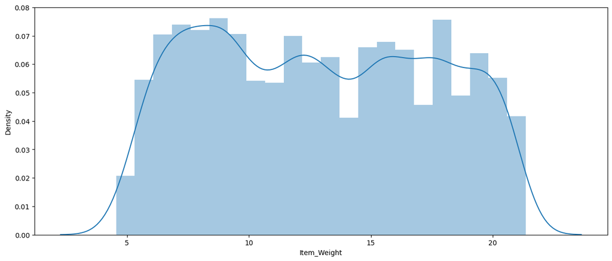

```python
#Disk Plot : Item_Weight
sns.distplot(df['Item_Weight'])
plt.show()
```

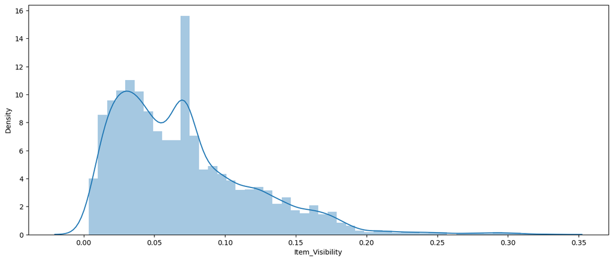

```python
#Disk Plot : Item_Visibility
sns.distplot(df['Item_Visibility'])
plt.show()
```

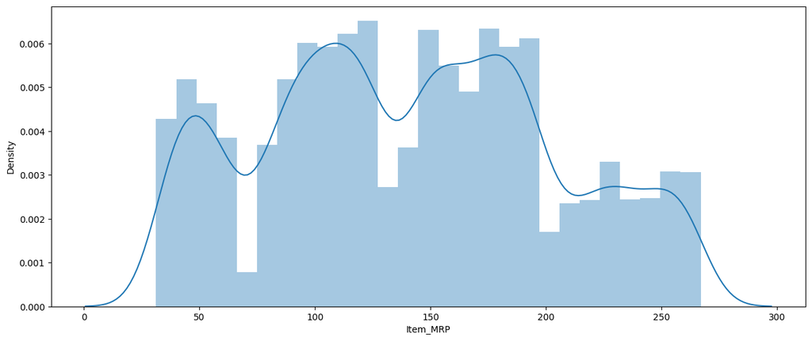

```python
#Disk Plot : Item_MRP
sns.distplot(df['Item_MRP'])
plt.show()
```

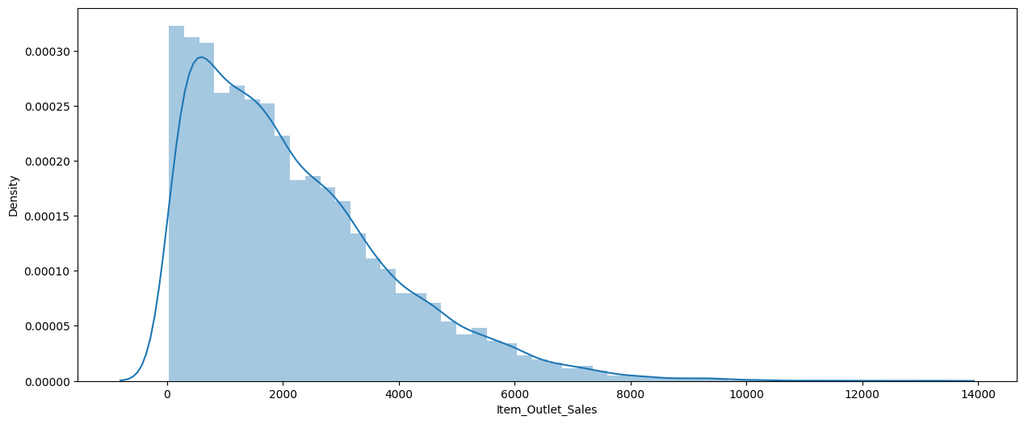

```python
#Disk Plot : Item_Outlet_Sales
sns.distplot(df['Item_Outlet_Sales'])
plt.show()
```

```python
#log transformation to reduce outliers : we do it as above outlet_sales distplat is right skewed and their might be outliers in left side as well
df['Item_Outlet_Sales']=np.log(1+df['Item_Outlet_Sales'])
display(df['Item_Outlet_Sales'])
```

```
0       8.225808
1       6.096776
2       7.648868
3       6.597664
4       6.903451
          ...
8518    7.929984
8519    6.310436
8520    7.085159
8521    7.521100
8522    6.642056
Name: Item_Outlet_Sales, Length: 8523, dtype: float64
```

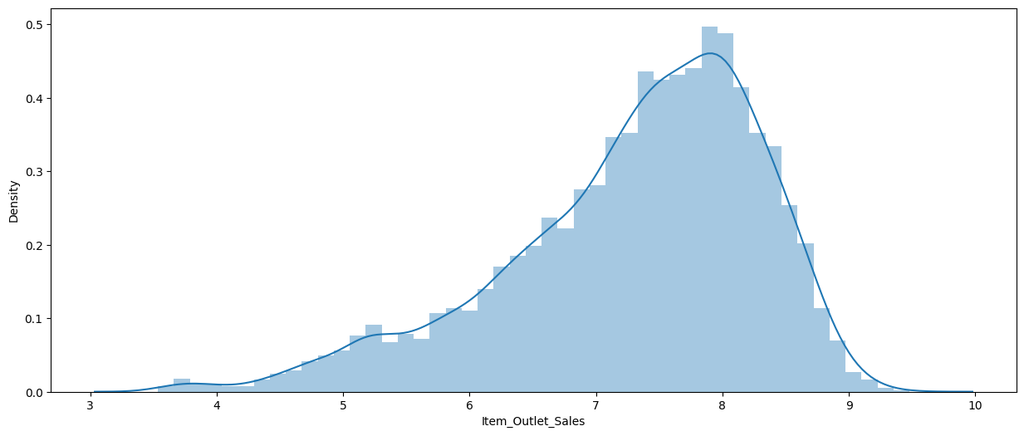

```python
#distplot again
sns.distplot(df['Item_Outlet_Sales'])
plt.show()
```

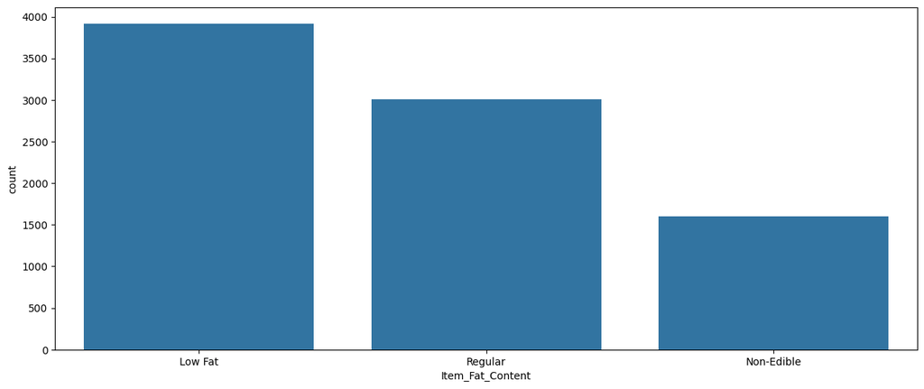

```python
#Count plot : Item_Fat_Content
sns.countplot(x=df['Item_Fat_Content'])
plt.show()
```

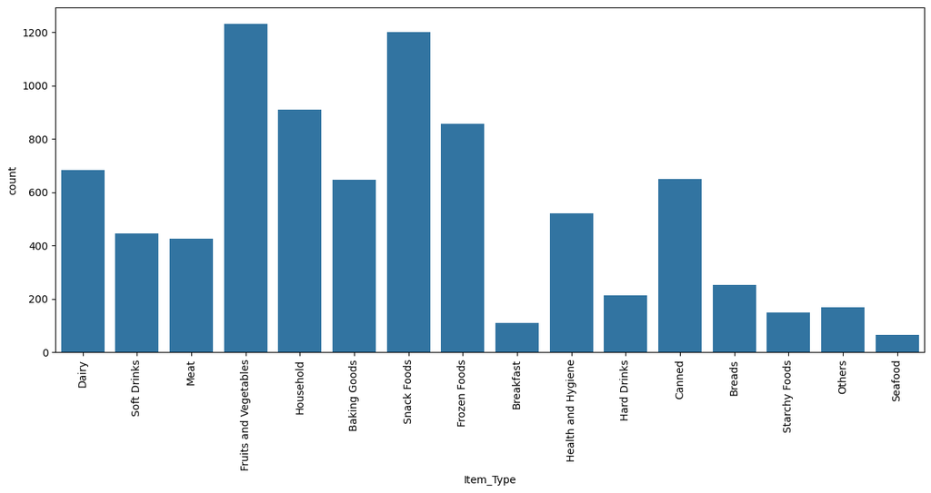

```python
#Count Plot : Item_Type
l=list(df['Item_Type'].unique())
chart=sns.countplot(x=df['Item_Type'])
chart.set_xticklabels(labels=l,rotation=90)
plt.show()
```

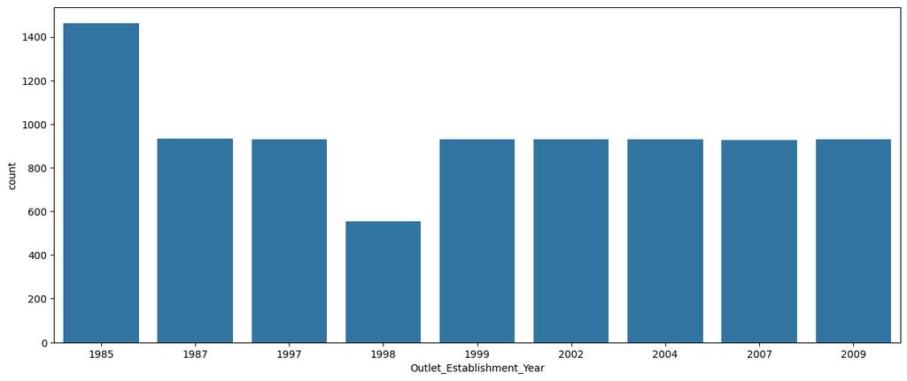

```python
#count plot : establishment year
sns.countplot(x=df['Outlet_Establishment_Year'])
plt.show()
```

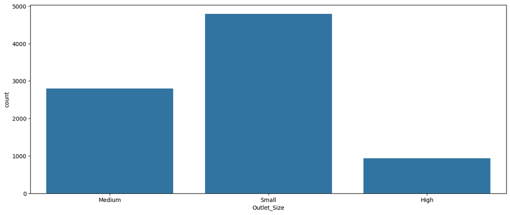

```python
#count plot : outlet size
sns.countplot(x=df['Outlet_Size'])
plt.show()
```

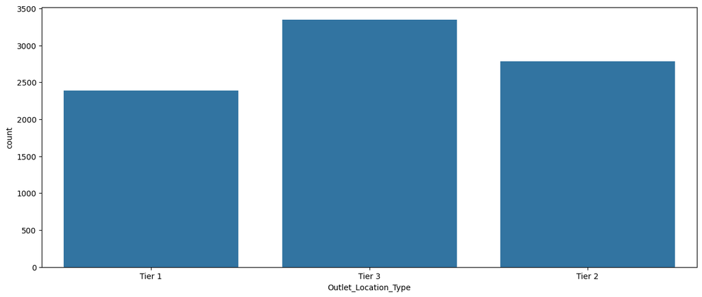

```python
#count plot : Outlet_Location_Type
sns.countplot(x=df['Outlet_Location_Type'])
plt.show()
```

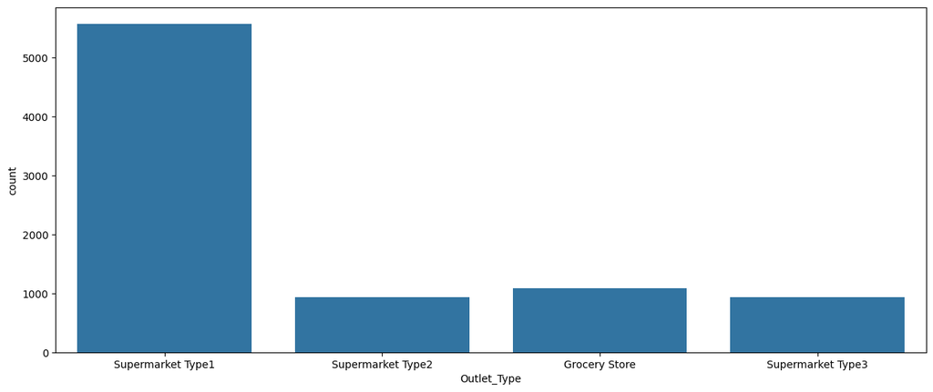

```python
#count plot : Outlet_Type
sns.countplot(x=df['Outlet_Type'])
plt.show()
```

```python
#Corelation matrix : It tells how independent variables are related . Also acorrelation matrix shows the relationship between numeric columns in your dataset.
#first display top 3 records to check columns with numeric values
display(df.head(3))
```

|  | Item_Identifier | Item_Weight | Item_Fat_Content | Item_Visibility | Item_Type | Item_MRP | Outlet_Identifier | Outlet_Establishment_Year | Outlet_Size | Outlet_Location_Type | Outlet_Type | Item_Outlet_Sales | New_Item_Type | Outlet_Years |
| --- | --- | --- | --- | --- | --- | --- | --- | --- | --- | --- | --- | --- | --- | --- |
| 0 | FDA15 | 9.30 | Low Fat | 0.016047 | Dairy | 249.8092 | OUT049 | 1999 | Medium | Tier 1 | Supermarket Type1 | 8.225808 | Food | 26 |
| 1 | DRC01 | 5.92 | Regular | 0.019278 | Soft Drinks | 48.2692 | OUT018 | 2009 | Medium | Tier 3 | Supermarket Type2 | 6.096776 | Drink | 16 |
| 2 | FDN15 | 17.50 | Low Fat | 0.016760 | Meat | 141.6180 | OUT049 | 1999 | Medium | Tier 1 | Supermarket Type1 | 7.648868 | Food | 26 |

```python
#Secondly Create a dataframe only for the numeric columns
dfc=df.iloc[:,[1,3,5,7,11,13]] #[1, 3, 5, 7, 11, 13] → selecting specific columns by their position in the DataFrame , ':' is all rows
display(dfc) #shows all rows only for columns=[1, 3, 5, 7, 11, 13]
```

|  | Item_Weight | Item_Visibility | Item_MRP | Outlet_Establishment_Year | Item_Outlet_Sales | Outlet_Years |
| --- | --- | --- | --- | --- | --- | --- |
| 0 | 9.300 | 0.016047 | 249.8092 | 1999 | 8.225808 | 26 |
| 1 | 5.920 | 0.019278 | 48.2692 | 2009 | 6.096776 | 16 |
| 2 | 17.500 | 0.016760 | 141.6180 | 1999 | 7.648868 | 26 |
| 3 | 19.200 | 0.070482 | 182.0950 | 1998 | 6.597664 | 27 |
| 4 | 8.930 | 0.070482 | 53.8614 | 1987 | 6.903451 | 38 |
| ... | ... | ... | ... | ... | ... | ... |
| 8518 | 6.865 | 0.056783 | 214.5218 | 1987 | 7.929984 | 38 |
| 8519 | 8.380 | 0.046982 | 108.1570 | 2002 | 6.310436 | 23 |
| 8520 | 10.600 | 0.035186 | 85.1224 | 2004 | 7.085159 | 21 |
| 8521 | 7.210 | 0.145221 | 103.1332 | 2009 | 7.521100 | 16 |
| 8522 | 14.800 | 0.044878 | 75.4670 | 1997 | 6.642056 | 28 |

8523 rows × 6 columns

```python
#Thirdly print correlation
corr=dfc.corr()
display(corr)
```

|  | Item_Weight | Item_Visibility | Item_MRP | Outlet_Establishment_Year | Item_Outlet_Sales | Outlet_Years |
| --- | --- | --- | --- | --- | --- | --- |
| Item_Weight | 1.000000 | -0.017992 | 0.025972 | -0.013418 | 0.007674 | 0.013418 |
| Item_Visibility | -0.017992 | 1.000000 | -0.005515 | -0.078316 | -0.202392 | 0.078316 |
| Item_MRP | 0.025972 | -0.005515 | 1.000000 | 0.005020 | 0.509886 | -0.005020 |
| Outlet_Establishment_Year | -0.013418 | -0.078316 | 0.005020 | 1.000000 | 0.077032 | -1.000000 |
| Item_Outlet_Sales | 0.007674 | -0.202392 | 0.509886 | 0.077032 | 1.000000 | -0.077032 |
| Outlet_Years | 0.013418 | 0.078316 | -0.005020 | -1.000000 | -0.077032 | 1.000000 |

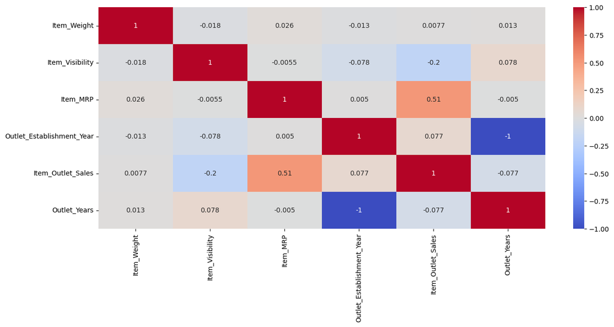

```python
#Fourthly print corelation matrix
sns.heatmap(corr,annot=True,cmap='coolwarm') #Red = Strong Positively corelated , Blue = Strong Negatively corelated , Near white = No correlation
plt.show()
```

*Conclusion of correlation matrix*

1. Item_MRP is the most important numeric feature affecting sales (positive correlation).
2. Item_Visibility has a weak negative effect on sales.
3. Item_Weight and Outlet_Age don’t contribute much to sales prediction.
4. Outlet_Establishment_Year and Outlet_Years are redundant (keep only one).

```python
from sklearn.preprocessing import LabelEncoder
le = LabelEncoder()
df['Outlet']=le.fit_transform(df['Outlet_Identifier'])
display(df['Outlet'])
```

```
0       9
1       3
2       9
3       0
4       1
       ..
8518    1
8519    7
8520    6
8521    3
8522    8
Name: Outlet, Length: 8523, dtype: int64
```

```python
#label encoding for remaining columns
cat_col=['Item_Fat_Content','Item_Type','Outlet_Size','Outlet_Location_Type','Outlet_Type','New_Item_Type']
for col in cat_col:
    df[col]=le.fit_transform(df[col])
display(df.head())
```

|  | Item_Identifier | Item_Weight | Item_Fat_Content | Item_Visibility | Item_Type | Item_MRP | Outlet_Identifier | Outlet_Establishment_Year | Outlet_Size | Outlet_Location_Type | Outlet_Type | Item_Outlet_Sales | New_Item_Type | Outlet_Years | Outlet |
| --- | --- | --- | --- | --- | --- | --- | --- | --- | --- | --- | --- | --- | --- | --- | --- |
| 0 | FDA15 | 9.30 | 0 | 0.016047 | 4 | 249.8092 | OUT049 | 1999 | 1 | 0 | 1 | 8.225808 | 1 | 26 | 9 |
| 1 | DRC01 | 5.92 | 2 | 0.019278 | 14 | 48.2692 | OUT018 | 2009 | 1 | 2 | 2 | 6.096776 | 0 | 16 | 3 |
| 2 | FDN15 | 17.50 | 0 | 0.016760 | 10 | 141.6180 | OUT049 | 1999 | 1 | 0 | 1 | 7.648868 | 1 | 26 | 9 |
| 3 | FDX07 | 19.20 | 2 | 0.070482 | 6 | 182.0950 | OUT010 | 1998 | 2 | 2 | 0 | 6.597664 | 1 | 27 | 0 |
| 4 | NCD19 | 8.93 | 1 | 0.070482 | 9 | 53.8614 | OUT013 | 1987 | 0 | 2 | 1 | 6.903451 | 2 | 38 | 1 |

```python
#One Hot Encoding
df = pd.get_dummies(df, columns=['Item_Fat_Content', 'Outlet_Size', 'Outlet_Location_Type', 'Outlet_Type', 'New_Item_Type'], dtype=int)
display(df.head())
```

|  | Item_Identifier | Item_Weight | Item_Visibility | Item_Type | Item_MRP | Outlet_Identifier | Outlet_Establishment_Year | Item_Outlet_Sales | Outlet_Years | Outlet | ... | Outlet_Location_Type_0 | Outlet_Location_Type_1 | Outlet_Location_Type_2 | Outlet_Type_0 | Outlet_Type_1 | Outlet_Type_2 | Outlet_Type_3 | New_Item_Type_0 | New_Item_Type_1 | New_Item_Type_2 |
| --- | --- | --- | --- | --- | --- | --- | --- | --- | --- | --- | --- | --- | --- | --- | --- | --- | --- | --- | --- | --- | --- |
| 0 | FDA15 | 9.30 | 0.016047 | 4 | 249.8092 | OUT049 | 1999 | 8.225808 | 26 | 9 | ... | 1 | 0 | 0 | 0 | 1 | 0 | 0 | 0 | 1 | 0 |
| 1 | DRC01 | 5.92 | 0.019278 | 14 | 48.2692 | OUT018 | 2009 | 6.096776 | 16 | 3 | ... | 0 | 0 | 1 | 0 | 0 | 1 | 0 | 1 | 0 | 0 |
| 2 | FDN15 | 17.50 | 0.016760 | 10 | 141.6180 | OUT049 | 1999 | 7.648868 | 26 | 9 | ... | 1 | 0 | 0 | 0 | 1 | 0 | 0 | 0 | 1 | 0 |
| 3 | FDX07 | 19.20 | 0.070482 | 6 | 182.0950 | OUT010 | 1998 | 6.597664 | 27 | 0 | ... | 0 | 0 | 1 | 1 | 0 | 0 | 0 | 0 | 1 | 0 |
| 4 | NCD19 | 8.93 | 0.070482 | 9 | 53.8614 | OUT013 | 1987 | 6.903451 | 38 | 1 | ... | 0 | 0 | 1 | 0 | 1 | 0 | 0 | 0 | 0 | 1 |

5 rows × 26 columns

```python
#Removing unused columns by creating X
X = df.drop(columns=['Outlet_Establishment_Year','Item_Identifier', 'Outlet_Identifier','Item_Outlet_Sales'])
display(X.head())
```

|  | Item_Weight | Item_Visibility | Item_Type | Item_MRP | Outlet_Years | Outlet | Item_Fat_Content_0 | Item_Fat_Content_1 | Item_Fat_Content_2 | Outlet_Size_0 | ... | Outlet_Location_Type_0 | Outlet_Location_Type_1 | Outlet_Location_Type_2 | Outlet_Type_0 | Outlet_Type_1 | Outlet_Type_2 | Outlet_Type_3 | New_Item_Type_0 | New_Item_Type_1 | New_Item_Type_2 |
| --- | --- | --- | --- | --- | --- | --- | --- | --- | --- | --- | --- | --- | --- | --- | --- | --- | --- | --- | --- | --- | --- |
| 0 | 9.30 | 0.016047 | 4 | 249.8092 | 26 | 9 | 1 | 0 | 0 | 0 | ... | 1 | 0 | 0 | 0 | 1 | 0 | 0 | 0 | 1 | 0 |
| 1 | 5.92 | 0.019278 | 14 | 48.2692 | 16 | 3 | 0 | 0 | 1 | 0 | ... | 0 | 0 | 1 | 0 | 0 | 1 | 0 | 1 | 0 | 0 |
| 2 | 17.50 | 0.016760 | 10 | 141.6180 | 26 | 9 | 1 | 0 | 0 | 0 | ... | 1 | 0 | 0 | 0 | 1 | 0 | 0 | 0 | 1 | 0 |
| 3 | 19.20 | 0.070482 | 6 | 182.0950 | 27 | 0 | 0 | 0 | 1 | 0 | ... | 0 | 0 | 1 | 1 | 0 | 0 | 0 | 0 | 1 | 0 |
| 4 | 8.93 | 0.070482 | 9 | 53.8614 | 38 | 1 | 0 | 1 | 0 | 1 | ... | 0 | 0 | 1 | 0 | 1 | 0 | 0 | 0 | 0 | 1 |

5 rows × 22 columns

```python
#checking outlet sales
y=df['Item_Outlet_Sales']
display(y.head())
```

```
0    8.225808
1    6.096776
2    7.648868
3    6.597664
4    6.903451
Name: Item_Outlet_Sales, dtype: float64
```

*Function to create ML model* : We will use diffn models and find the best one to use

```python
from sklearn import metrics
display(",  ".join(metrics.get_scorer_names()))
```

[output not shown]

```python
from sklearn.model_selection import cross_val_score
from sklearn.metrics import mean_squared_error
from sklearn.metrics import r2_score
```

```python
def train(model, X,y):
    print ("Train Test Split")
    from sklearn.model_selection import train_test_split
    X_train, X_test, y_train, y_test = train_test_split(X, y, test_size=0.3, random_state=0)
    print (X.shape, y.shape)
    print (X_train.shape, X_test.shape ,  y_train.shape, y_test.shape)

    # training the model
    model.fit(X_train, y_train)

    # perform cross-validation
    cv_score = cross_val_score(model, X, y, scoring='neg_mean_squared_error', cv=5)
    print("Model Report")
    print ('Scoring - neg_mean_squared_error')
    print ( cv_score )
    cv_score = np.abs(np.mean(cv_score))
    print ('ABS Average of - neg_mean_squared_error',cv_score )
    cv_score = cross_val_score(model, X, y,  cv=5)
    print ()
    print ('R2 Score ')
    print ( cv_score )
    cv_score = np.mean(cv_score)
    print ('Average R2 Score ',cv_score)
    print ()

    # Display Accuracy
    print ('Accuracy')
    print ('Accuracy of Test data')
    y_test_pred = model.predict(X_test)
    print('R2_Score:', r2_score(y_test,y_test_pred))
    print ('Accuracy of Training data')
    y_train_pred = model.predict(X_train)
    print('R2_Score:', r2_score(y_train,y_train_pred))
    print ('Accuracy of Complete data')
    y_pred = model.predict(X)
    print('R2_Score:', r2_score(y,y_pred))
    print ()

    # Display graph with actual and predicted values

    plt.subplot (212)
    print ('Display actual and predicted values')
    sns.regplot( x =y, y= y_pred, scatter_kws={"color": "b"},
            line_kws={"color": "r"},ci = None)
    plt.show()
```

```
Train Test Split
(8523, 22) (8523,)
(5966, 22) (2557, 22) (5966,) (2557,)
Model Report
Scoring - neg_mean_squared_error
[-0.29362614 -0.2985575  -0.28488226 -0.28840311 -0.28022569]
ABS Average of - neg_mean_squared_error 0.28913894049107103

R2 Score
[0.72122041 0.71063485 0.70745942 0.71542343 0.74010277]
Average R2 Score  0.7189681763813924

Accuracy
Accuracy of Test data
R2_Score: 0.7136388390159893
Accuracy of Training data
R2_Score: 0.7232617915013884
Accuracy of Complete data
R2_Score: 0.7203104555958092

Display actual and predicted values
```

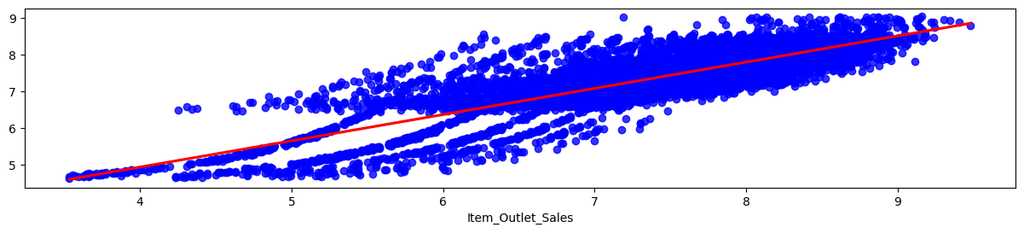

```
Outlet_Type_0            -1.254875
Outlet_Size_1            -0.735119
Outlet_Size_2            -0.575260
Outlet_Type_1            -0.476439
Outlet_Location_Type_2   -0.383771
Outlet_Type_2            -0.293304
Outlet_Years             -0.073228
Item_Visibility          -0.034015
New_Item_Type_0          -0.026513
Item_Fat_Content_0       -0.010452
Item_Weight              -0.001516
Item_Type                 0.000925
Item_Fat_Content_2        0.005062
New_Item_Type_2           0.005390
Item_Fat_Content_1        0.005390
Item_MRP                  0.008172
New_Item_Type_1           0.021123
Outlet_Location_Type_1    0.030344
Outlet                    0.061954
Outlet_Location_Type_0    0.353428
Outlet_Size_0             1.310378
Outlet_Type_3             2.024618
dtype: float64
```

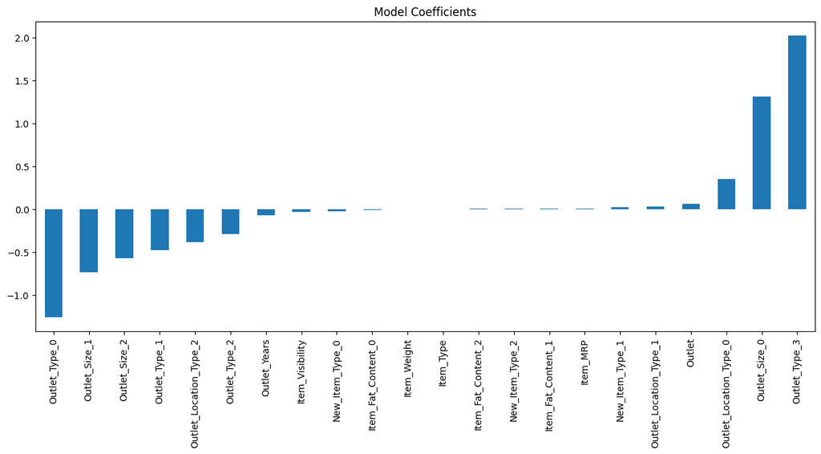

```python
#Linear Regression model
from sklearn.linear_model import LinearRegression
model = LinearRegression()
train(model, X,y)
coef = pd.Series(model.coef_, X.columns).sort_values()
print (coef)
coef.plot(kind='bar', title="Model Coefficients")
plt.show()
```

```
Train Test Split
(8523, 22) (8523,)
(5966, 22) (2557, 22) (5966,) (2557,)
Model Report
Scoring - neg_mean_squared_error
[-0.29318262 -0.29900924 -0.28516961 -0.28876841 -0.28047734]
ABS Average of - neg_mean_squared_error 0.28932144308931584

R2 Score
[0.72164151 0.71019702 0.70716435 0.71506298 0.73986938]
Average R2 Score  0.7187870459103919

Accuracy
Accuracy of Test data
R2_Score: 0.7132084530824039
Accuracy of Training data
R2_Score: 0.7230799671083096
Accuracy of Complete data
R2_Score: 0.7200523343256965

Display actual and predicted values
```

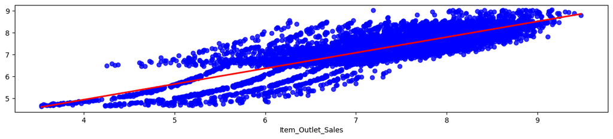

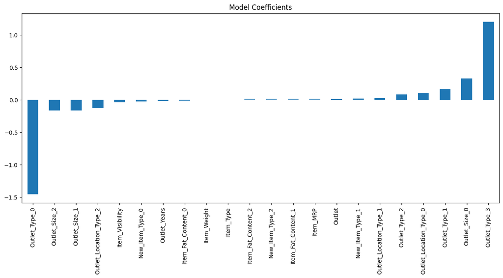

```python
#Ridge Regression Model
from sklearn.linear_model import Ridge
model = Ridge()
train(model, X,y)
coef = pd.Series(model.coef_, X.columns).sort_values()
coef.plot(kind='bar', title="Model Coefficients")
plt.show()
```

```
Train Test Split
(8523, 22) (8523,)
(5966, 22) (2557, 22) (5966,) (2557,)
Model Report
Scoring - neg_mean_squared_error
[-0.76444141 -0.75797033 -0.72014686 -0.75959604 -0.81323995]
ABS Average of - neg_mean_squared_error 0.7630789166281843

R2 Score
[0.27421086 0.26536699 0.26049386 0.2504823  0.24575506]
Average R2 Score  0.2592618151206076

Accuracy
Accuracy of Test data
R2_Score: 0.2538352830427828
Accuracy of Training data
R2_Score: 0.26227683517122646
Accuracy of Complete data
R2_Score: 0.2596923551013076

Display actual and predicted values
```

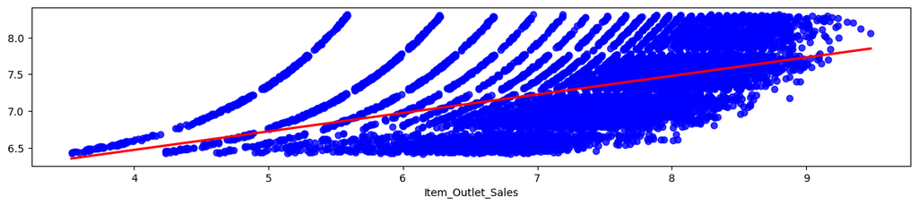

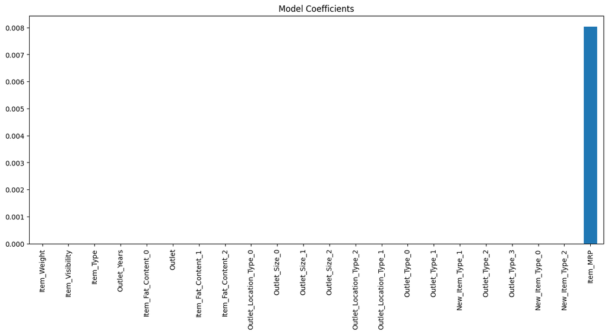

```python
#Lasso Regression
from sklearn.linear_model import Lasso
model = Lasso()
train(model, X,y)
coef = pd.Series(model.coef_, X.columns).sort_values()
coef.plot(kind='bar', title="Model Coefficients")
plt.show()
```

```
Train Test Split
(8523, 22) (8523,)
(5966, 22) (2557, 22) (5966,) (2557,)
Model Report
Scoring - neg_mean_squared_error
[-0.57372191 -0.59308832 -0.56492755 -0.60909671 -0.54462354]
ABS Average of - neg_mean_squared_error 0.5770916058404201

R2 Score
[0.44778954 0.42041145 0.42580907 0.39636863 0.50045536]
Average R2 Score  0.43816681065848345

Accuracy
Accuracy of Test data
R2_Score: 0.449557642133388
Accuracy of Training data
R2_Score: 1.0
Accuracy of Complete data
R2_Score: 0.8310360185474772

Display actual and predicted values
```

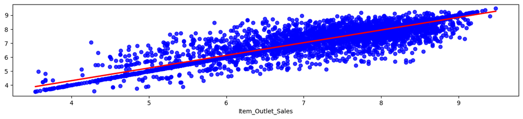

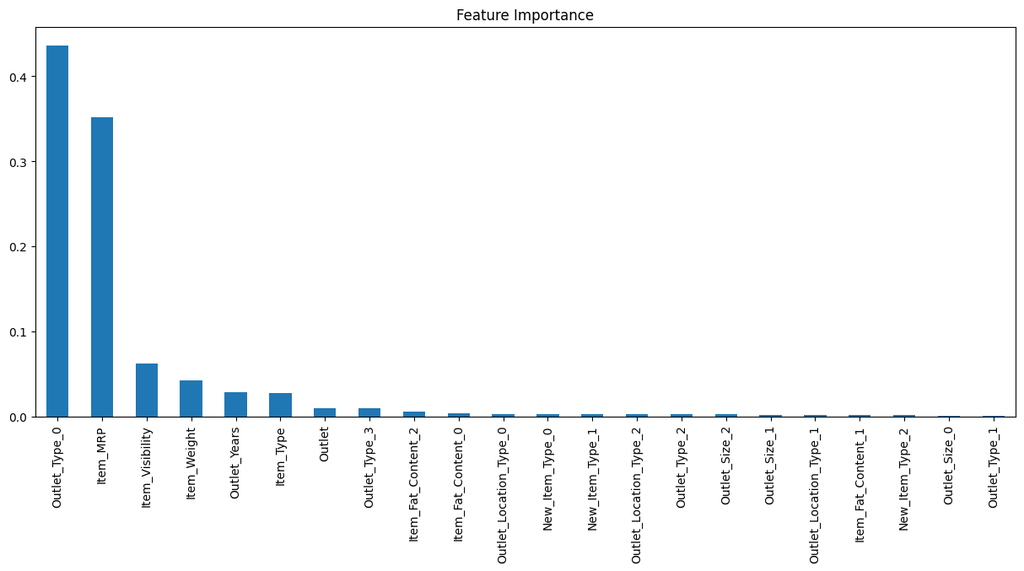

```python
#Decision Tree Regression
from sklearn.tree import DecisionTreeRegressor
model = DecisionTreeRegressor()
train(model, X,y)
coef = pd.Series(model.feature_importances_, X.columns).sort_values(ascending=False)
coef.plot(kind='bar', title="Feature Importance")
plt.show()
```

```
Train Test Split
(8523, 22) (8523,)
(5966, 22) (2557, 22) (5966,) (2557,)
Model Report
Scoring - neg_mean_squared_error
[-0.31503815 -0.32129945 -0.29713858 -0.31539719 -0.29953067]
ABS Average of - neg_mean_squared_error 0.30968080832523404

R2 Score
[0.70252859 0.68996768 0.69155929 0.6920925  0.72245174]
Average R2 Score  0.6997199626019093

Accuracy
Accuracy of Test data
R2_Score: 0.695726930938879
Accuracy of Training data
R2_Score: 0.9594649931660333
Accuracy of Complete data
R2_Score: 0.8785082344515127

Display actual and predicted values
```

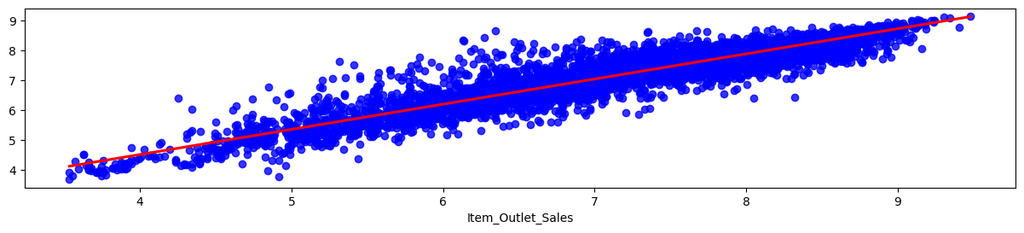

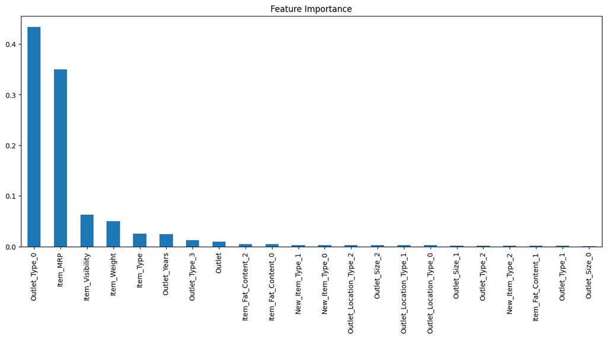

```python
#Random Forest Regression
from sklearn.ensemble import RandomForestRegressor
model = RandomForestRegressor()
train(model, X,y)
coef = pd.Series(model.feature_importances_, X.columns).sort_values(ascending=False)
coef.plot(kind='bar', title="Feature Importance")
plt.show()
```

```
Train Test Split
(8523, 22) (8523,)
(5966, 22) (2557, 22) (5966,) (2557,)
Model Report
Scoring - neg_mean_squared_error
[-0.33200122 -0.33701633 -0.31805433 -0.33670549 -0.31977911]
ABS Average of - neg_mean_squared_error 0.3287112960321023

R2 Score
[0.68792534 0.67277311 0.66918918 0.66932435 0.70072689]
Average R2 Score  0.6799877753342909

Accuracy
Accuracy of Test data
R2_Score: 0.6811879096228586
Accuracy of Training data
R2_Score: 1.0
Accuracy of Complete data
R2_Score: 0.9021373276320842

Display actual and predicted values
```

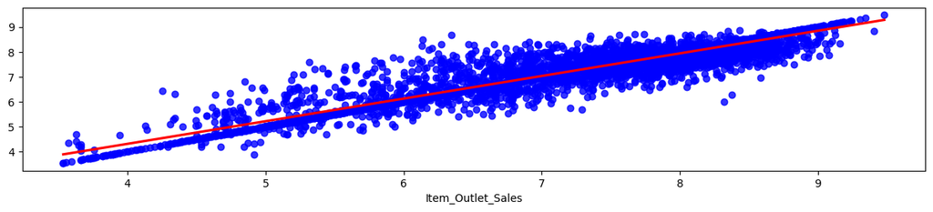

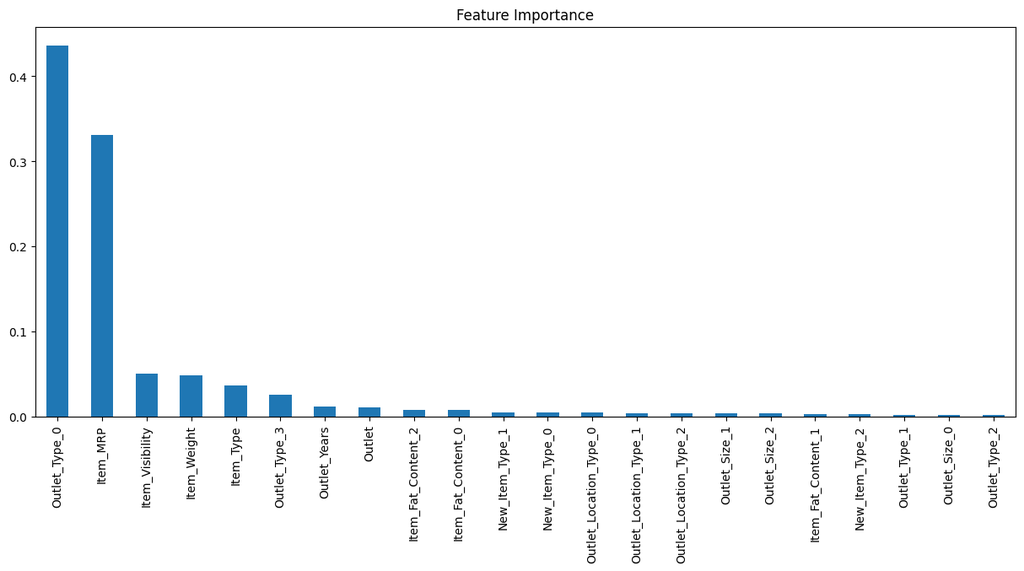

```python
#Extra Tree Regression
from sklearn.ensemble import ExtraTreesRegressor
model = ExtraTreesRegressor()
train(model, X,y)
coef = pd.Series(model.feature_importances_, X.columns).sort_values(ascending=False)
coef.plot(kind='bar', title="Feature Importance")
plt.show()
```

```
Train Test Split
(8523, 22) (8523,)
(5966, 22) (2557, 22) (5966,) (2557,)
Model Report
Scoring - neg_mean_squared_error
[-0.29205858 -0.28892291 -0.27461071 -0.27989913 -0.26844501]
ABS Average of - neg_mean_squared_error 0.28078727151197513

R2 Score
[0.72270871 0.7199728  0.71800709 0.72381457 0.75102885]
Average R2 Score  0.7271064020447748

Accuracy
Accuracy of Test data
R2_Score: 0.7211416509559052
Accuracy of Training data
R2_Score: 0.8160886932314251
Accuracy of Complete data
R2_Score: 0.7869453961441336

Display actual and predicted values
```

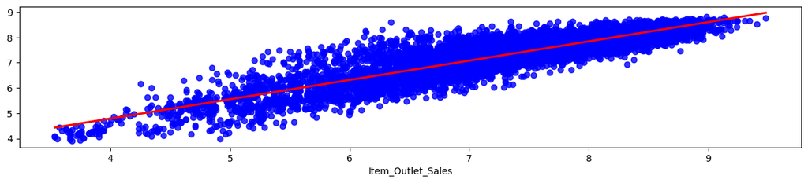

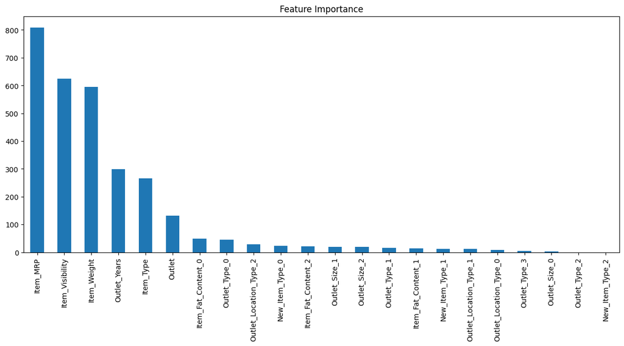

```python
#LGBMRegressor
from lightgbm import LGBMRegressor
model = LGBMRegressor(verbosity=-1)
train(model, X,y)
coef = pd.Series(model.feature_importances_, X.columns).sort_values(ascending=False)
coef.plot(kind='bar', title="Feature Importance")
plt.show()
```

```
Train Test Split
(8523, 22) (8523,)
(5966, 22) (2557, 22) (5966,) (2557,)
Model Report
Scoring - neg_mean_squared_error
[-0.33129026 -0.32617091 -0.31447181 -0.32851087 -0.30068846]
ABS Average of - neg_mean_squared_error 0.32022646300445273

R2 Score
[0.68546069 0.68387164 0.67707443 0.67584782 0.72112444]
Average R2 Score  0.6886758026950668

Accuracy
Accuracy of Test data
R2_Score: 0.6786971691106711
Accuracy of Training data
R2_Score: 0.9164205403943537
Accuracy of Complete data
R2_Score: 0.8434496538077183

Display actual and predicted values
```

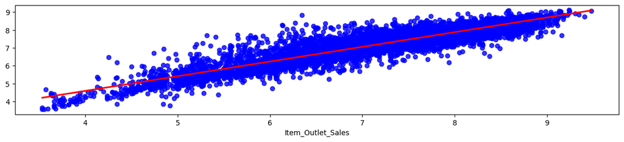

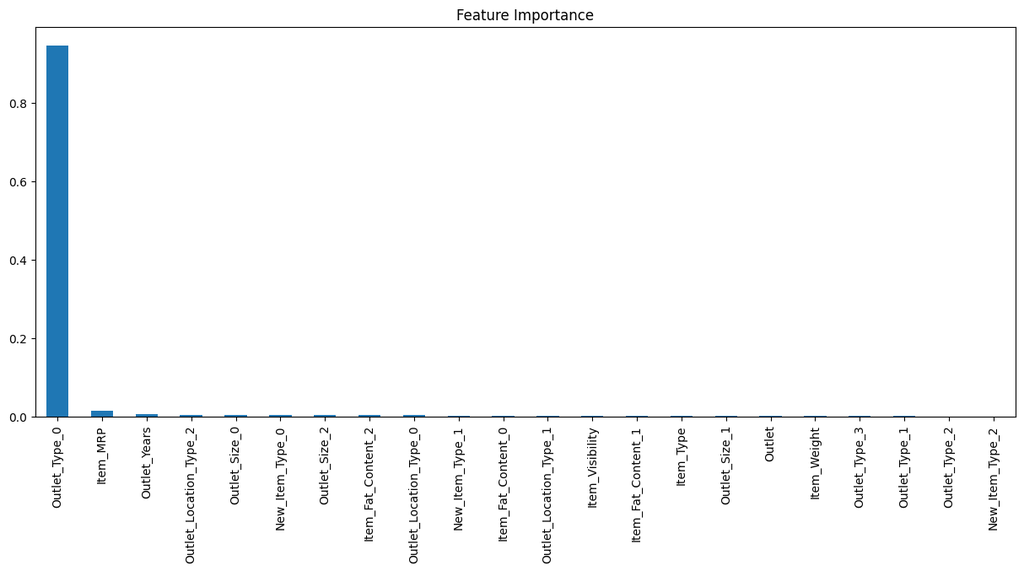

```python
#XG Boost Regressor
from xgboost import XGBRegressor
model = XGBRegressor()
train(model, X,y)
coef = pd.Series(model.feature_importances_, X.columns).sort_values(ascending=False)
coef.plot(kind='bar', title="Feature Importance")
plt.show()
```

```python
#Train Test Split
from sklearn.model_selection import train_test_split
X_train, X_test, y_train, y_test = train_test_split(X, y, test_size=0.3, random_state=0)
print (X.shape, y.shape)
print (X_train.shape, X_test.shape ,  y_train.shape, y_test.shape)
```

```
(8523, 22) (8523,)
(5966, 22) (2557, 22) (5966,) (2557,)
```

```python
#Parameters
max_features = ['auto', 'sqrt']
max_depth = [int(x) for x in np.linspace(5, 30, num = 6)]
min_samples_split = [2, 5, 10, 15, 100]
min_samples_leaf = [1, 2, 5, 10]
```

```python
#Param Grid
random_grid = {'max_features': max_features,'max_depth': max_depth,'min_samples_split': min_samples_split,'min_samples_leaf': min_samples_leaf}
print(random_grid)
```

```
{'max_features': ['auto', 'sqrt'], 'max_depth': [5, 10, 15, 20, 25, 30], 'min_samples_split': [2, 5, 10, 15, 100], 'min_samples_leaf': [1, 2, 5, 10]}
```

```python
#Random Forest Regression
from sklearn.model_selection import RandomizedSearchCV
rf = RandomForestRegressor()
rf=RandomizedSearchCV(estimator = rf, param_distributions = random_grid,scoring='neg_mean_squared_error', n_iter = 30, cv = 5, verbose= 1, random_state=42, n_jobs = -1)
display (rf.fit(X_train, y_train))
```

```
Fitting 5 folds for each of 30 candidates, totalling 150 fits
```

```
RandomizedSearchCV(cv=5, estimator=RandomForestRegressor(), n_iter=30,
                   n_jobs=-1,
                   param_distributions={'max_depth': [5, 10, 15, 20, 25, 30],
                                        'max_features': ['auto', 'sqrt'],
                                        'min_samples_leaf': [1, 2, 5, 10],
                                        'min_samples_split': [2, 5, 10, 15,
                                                              100]},
                   random_state=42, scoring='neg_mean_squared_error',
                   verbose=1)
```

```python
#Best Parameters  and Plot Graph

print(rf.best_params_)
print(rf.best_score_)

# Display Accuracy
print ()
```

```
{'min_samples_split': 15, 'min_samples_leaf': 1, 'max_features': 'sqrt', 'max_depth': 20}
-0.2865465315658682
```

```python
print ('Accuracy')
print ('Accuracy of Test data')
y_test_pred = rf.predict(X_test)
print('R2_Score:', r2_score(y_test,y_test_pred))
print ('Accuracy of Training data')
y_train_pred = rf.predict(X_train)
print('R2_Score:', r2_score(y_train,y_train_pred))
print ('Accuracy of Complete data')
y_pred = rf.predict(X)
print('R2_Score:', r2_score(y,y_pred))
print ()
```

```
Accuracy
Accuracy of Test data
R2_Score: 0.7126174265883478
Accuracy of Training data
R2_Score: 0.8288419006729044
Accuracy of Complete data
R2_Score: 0.7931671590222411
```

```
Display actual and predicted values
```

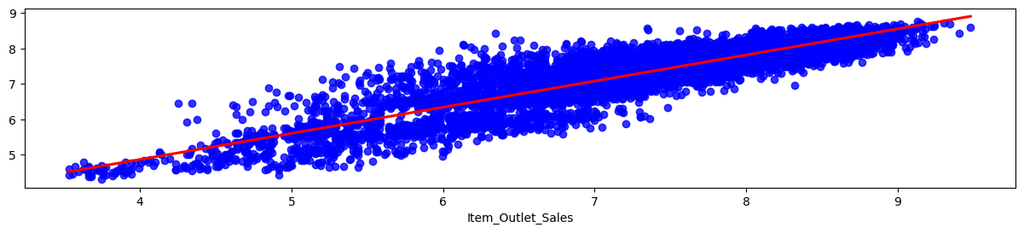

```python
# Display graph with actual and predicted values
plt.subplot (212)
print ('Display actual and predicted values')
sns.regplot( x =y, y= y_pred, scatter_kws={"color": "b"}, line_kws={"color": "r"},ci = None)
plt.show()
```

```python
#Parameter for LGBM Regressor
from scipy.stats import uniform, randint
params = {
    "gamma": uniform(0, 0.5),
    "learning_rate": uniform(0.03, 0.3), # default 0.1
    "max_depth": randint(2, 6), # default 3
    "n_estimators": randint(100, 150), # default 100
    "subsample": uniform(0.6, 0.4)
}
```

```python
#Model LGBM Regressor
lgb=LGBMRegressor(verbosity=-1)
lgb = RandomizedSearchCV(estimator = lgb, param_distributions = params,scoring='neg_mean_squared_error', n_iter = 30, cv = 5, verbose=1, random_state=42, n_jobs = 1)
lgb.fit(X,y)
```

```
Fitting 5 folds for each of 30 candidates, totalling 150 fits
```

```
RandomizedSearchCV(cv=5, estimator=LGBMRegressor(verbosity=-1), n_iter=30,
                   n_jobs=1,
                   param_distributions={'gamma': <scipy.stats._distn_infrastructure.rv_continuous_frozen object at 0x0000016E006206E0>,
                                        'learning_rate': <scipy.stats._distn_infrastructure.rv_continuous_frozen object at 0x0000016E7DD90190>,
                                        'max_depth': <scipy.stats._distn_infrastructure.rv_discrete_frozen object at 0x0000016E02D41E80>,
                                        'n_estimators': <scipy.stats._distn_infrastructure.rv_discrete_frozen object at 0x0000016E7DD90550>,
                                        'subsample': <scipy.stats._distn_infrastructure.rv_continuous_frozen object at 0x0000016E7DD907D0>},
                   random_state=42, scoring='neg_mean_squared_error',
                   verbose=1)
```

```
{'gamma': np.float64(0.3121770240668966), 'learning_rate': np.float64(0.1186901057513142), 'max_depth': 2, 'n_estimators': 105, 'subsample': np.float64(0.782613828193164)}
-0.2699864821126824

Accuracy
Accuracy of Test data
R2_Score: 0.7416317223731326
Accuracy of Training data
R2_Score: 0.7504525429988252
Accuracy of Complete data
R2_Score: 0.7477471812877298

Display actual and predicted values
```

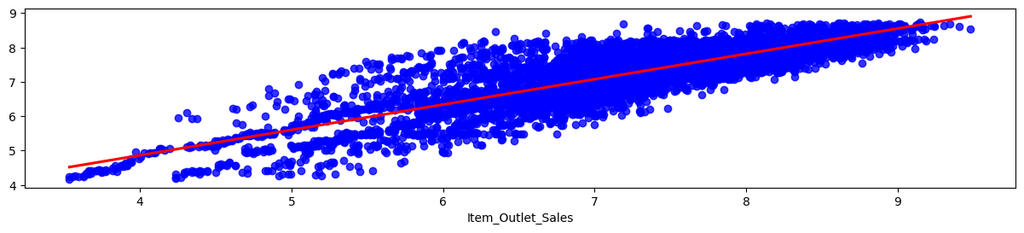

```python
#Best Parameter  and plot Graph

print(lgb.best_params_)
print(lgb.best_score_)

# Display Accuracy
print ()
print ('Accuracy')
print ('Accuracy of Test data')
y_test_pred = lgb.predict(X_test)
print('R2_Score:', r2_score(y_test,y_test_pred))
print ('Accuracy of Training data')
y_train_pred = lgb.predict(X_train)
print('R2_Score:', r2_score(y_train,y_train_pred))
print ('Accuracy of Complete data')
y_pred = lgb.predict(X)
print('R2_Score:', r2_score(y,y_pred))
print ()

# Display graph with actual and predicted values

plt.subplot (212)
print ('Display actual and predicted values')
sns.regplot( x =y, y= y_pred, scatter_kws={"color": "b"}, line_kws={"color": "r"},ci = None)
plt.show()
```

```python
#Model XG Boost
params = {
    "gamma": uniform(0, 0.5),
    "learning_rate": uniform(0.03, 0.3), # default 0.1
    "max_depth": randint(2, 6), # default 3
    "n_estimators": randint(100, 150), # default 100
    "subsample": uniform(0.6, 0.4)
}
```

```python
#XG Boost Regressor

from xgboost import XGBRegressor
model = XGBRegressor()
xgb = RandomizedSearchCV(estimator = model, param_distributions = params,scoring='neg_mean_squared_error', n_iter = 30, cv = 5, verbose=1, random_state=42, n_jobs = 1)
xgb.fit(X,y)
```

```
Fitting 5 folds for each of 30 candidates, totalling 150 fits
```

```
RandomizedSearchCV(cv=5,
                   estimator=XGBRegressor(base_score=None, booster=None,
                                          callbacks=None,
                                          colsample_bylevel=None,
                                          colsample_bynode=None,
                                          colsample_bytree=None, device=None,
                                          early_stopping_rounds=None,
                                          enable_categorical=False,
                                          eval_metric=None, feature_types=None,
                                          feature_weights=None, gamma=None,
                                          grow_policy=None,
                                          importance_type=None,
                                          interaction_constraint...
                                        'learning_rate': <scipy.stats._distn_infrastructure.rv_continuous_frozen object at 0x0000016E02CF4050>,
                                        'max_depth': <scipy.stats._distn_infrastructure.rv_discrete_frozen object at 0x0000016E78B3A990>,
                                        'n_estimators': <scipy.stats._distn_infrastructure.rv_discrete_frozen object at 0x0000016E02CF42B0>,
                                        'subsample': <scipy.stats._distn_infrastructure.rv_continuous_frozen object at 0x0000016E02CEED50>},
                   random_state=42, scoring='neg_mean_squared_error',
                   verbose=1)
```

```
{'gamma': np.float64(0.22007624686980065), 'learning_rate': np.float64(0.06661147045343364), 'max_depth': 2, 'n_estimators': 107, 'subsample': np.float64(0.6137554084460873)}
-0.270201149478229

Accuracy
Accuracy of Test data
R2_Score: 0.7391462872199867
Accuracy of Training data
R2_Score: 0.7472595395992374
Accuracy of Complete data
R2_Score: 0.7447714024677168

Display actual and predicted values
```

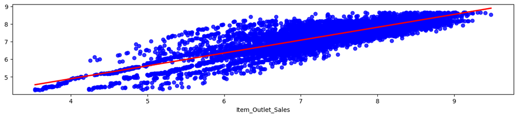

```python
#Print Best Parameter   and plot Graph

print(xgb.best_params_)
print(xgb.best_score_)

# Display Accuracy
print ()
print ('Accuracy')
print ('Accuracy of Test data')
y_test_pred = xgb.predict(X_test)
print('R2_Score:', r2_score(y_test,y_test_pred))
print ('Accuracy of Training data')
y_train_pred = xgb.predict(X_train)
print('R2_Score:', r2_score(y_train,y_train_pred))
print ('Accuracy of Complete data')
y_pred = xgb.predict(X)
print('R2_Score:', r2_score(y,y_pred))
print ()

# Display graph with actual and predicted values

plt.subplot (212)
print ('Display actual and predicted values')
sns.regplot( x =y, y= y_pred, scatter_kws={"color": "b"}, line_kws={"color": "r"},ci = None)
plt.show()
```

*Conclusion*:

1. Use LightGBM Regressor or XGBoost Regressor as the final model.
2. LightGBM is slightly faster and handles categorical features well if you extend your pipeline.
3. Random Forest is a solid alternative if interpretability and simplicity are preferred.